# Text Mining, Chapter 7

Case Study: Leviev Air (2)

Author

Texbook Author, modified by Jae Min Jung

Published

May 3, 2026

[figure not shown]

# 1 Introduction

## 1.1 Case Background

After an initial meeting in which you presented your first insights from the user-generated-data research project in Chater 5, the question comes up, if one can find more insights from the reviews and review headlines of the different airlines.

The board is especially interested to learn if there are general patterns and topics passengers debate about when flying. The board is also interested in finding a way to measure **brand equity** and **customer satisfaction** of the competing airlines to develop an **industry dashboard** that tracks brand equity and customer satisfaction for the **most prominent airlines**.

At best, you would come up with an approach that allows tracking brand equity from various user generated content sources such as airline reviews, but also social media networks such as Twitter or Instagram. The next day you sit down and pull all reviews available for all major airlines flying from London Heathrow and start running your analysis to answer the following **questions**

1. Which airlines do see more reviews than others?
2. Which common issues do customers praise when flying?
3. Which common issues do customers complain about most, when flying?
4. How does sentiment relate to customer experience?
5. How do passengers use emotions in their feedback when talking about different airlines?
6. Can we leverage the review data to build a brand equity measure?
7. Can we develop our own text-sentiment classifier to harvest airline sentiment from social media?

## 1.2 Packages

## 1.3 Comparison of Major Text Mining Packages

| Feature | `tm` | `tidytext` | `text2vec` | `quanteda` |
| --- | --- | --- | --- | --- |
| Released | 2008 | 2016 | 2016 | 2016 |
| Philosophy | OOP, own data structures | Tidy data principles | High performance | Comprehensive NLP |
| Data format | Corpus object | Data frames / tibbles | Sparse matrices | Corpus + tokens objects |
| Learning curve | Moderate | Low | Moderate | Moderate |
| Speed | Moderate | Moderate | **Very fast** | Fast |
| Large datasets | Limited | Limited | **Excellent** | Good |
| tidyverse compatible | No | **Yes** | Partial | Partial |
| ML ready output | DTM/TDM | Needs conversion | **Direct sparse matrix** | DTM/TDM |

#### 1.3.0.1 When to Use Each Package

| Use Case | Recommended Package |
| --- | --- |
| Quick exploratory analysis | `tidytext` |
| Building ML classifiers | `text2vec` |
| Legacy code maintenance | `tm` |
| Advanced NLP tasks | `quanteda` |
| Working within tidyverse | `tidytext` |
| Very large text datasets | `text2vec` |
| Social media analysis | `tidytext` + `vader` |

#### 1.3.0.2 The Modern Trend

While `tm` was the **go-to package for many years** and you will still find it in many textbooks and older code, the R text mining ecosystem has largely shifted toward:

- `tidytext` for exploratory analysis and visualization
- `text2vec` for machine learning pipelines
- `quanteda` for advanced NLP

That said, `tm` is still worth knowing because a lot of existing code, tutorials, and academic papers use it, and its `Corpus` and `DocumentTermMatrix` objects are widely referenced in the text mining literature.

## 1.4 Reading Data

````markdown
```{r}
#| label: loading-data
Airline_Reviews_Leviev <- read_csv("data/airlinereviews.csv")
```
````

```
──────────────────────────────────────────────────────── Delimiter: "," chr
(9): review_written, Airline, route, title, review_text, aircraft, type_... dbl
(2): ...1, overall_rating
```

````markdown
```{r}
#| label: reviews-by-airlines
Airline_Reviews_Leviev |> glimpse()

Airline_Reviews_Leviev |>
  count(Airline) |>
  mutate(percent = n / sum(n)) |>
  mutate(total_reviews = sum(n)) |>
  arrange(-n)
```
````

```
Rows: 24,391
Columns: 11
$ ...1              <dbl> 1, 2, 3, 4, 5, 6, 7, 8, 9, 10, 11, 12, 13, 14, 15, 1…
$ review_written    <chr> "7th January 2021", "5th January 2021", "5th January…
$ Airline           <chr> "Air Canada", "Air Canada", "Air Canada", "Air Canad…
$ route             <chr> "Washington to Beirut", "Toronto to Mumbai", "Vancou…
$ overall_rating    <dbl> 1, 2, 6, 1, 10, 1, 1, 1, 1, 2, 1, 9, 1, 1, 9, 1, 1, …
$ title             <chr> "\"Very bad service and customer support\"", "\"plea…
$ review_text       <chr> "|Very bad service and customer support. They change…
$ aircraft          <chr> NA, NA, "A321", NA, NA, NA, NA, NA, NA, "Boeing 787-…
$ type_of_traveller <chr> "Solo Leisure", "Solo Leisure", "Solo Leisure", "Cou…
$ seat_type         <chr> "Economy Class", "Economy Class", "Economy Class", "…
$ recommendation    <chr> "no", "no", "yes", "no", "yes", "no", "no", "no", "n…
```

| Airline | n | percent | total_reviews |
| --- | --- | --- | --- |
| United Airlines | 3457 | 0.14173261 | 24391 |
| British Airways | 3149 | 0.12910500 | 24391 |
| Emirates | 2031 | 0.08326842 | 24391 |
| Turkish Airlines | 1838 | 0.07535566 | 24391 |
| Qatar Airways | 1748 | 0.07166578 | 24391 |
| Lufthansa | 1694 | 0.06945185 | 24391 |
| Air Canada | 1565 | 0.06416301 | 24391 |
| Etihad Airways | 1524 | 0.06248206 | 24391 |
| Singapore Airlines | 1278 | 0.05239638 | 24391 |
| Southwest Airlines | 1182 | 0.04846050 | 24391 |

[output cut: 6 more lines]

- The data set consists of 24,391 reviews from 16 different major airlines and thus provides a sufficient level of information to base our analysis on.
- To explore the number of reviews per airline we can use the following code that will give us a plot and the relative share of reviews per airline.

# 2 Exploratory Data Analysis

## 2.1 Proportion of Reviews by Airline

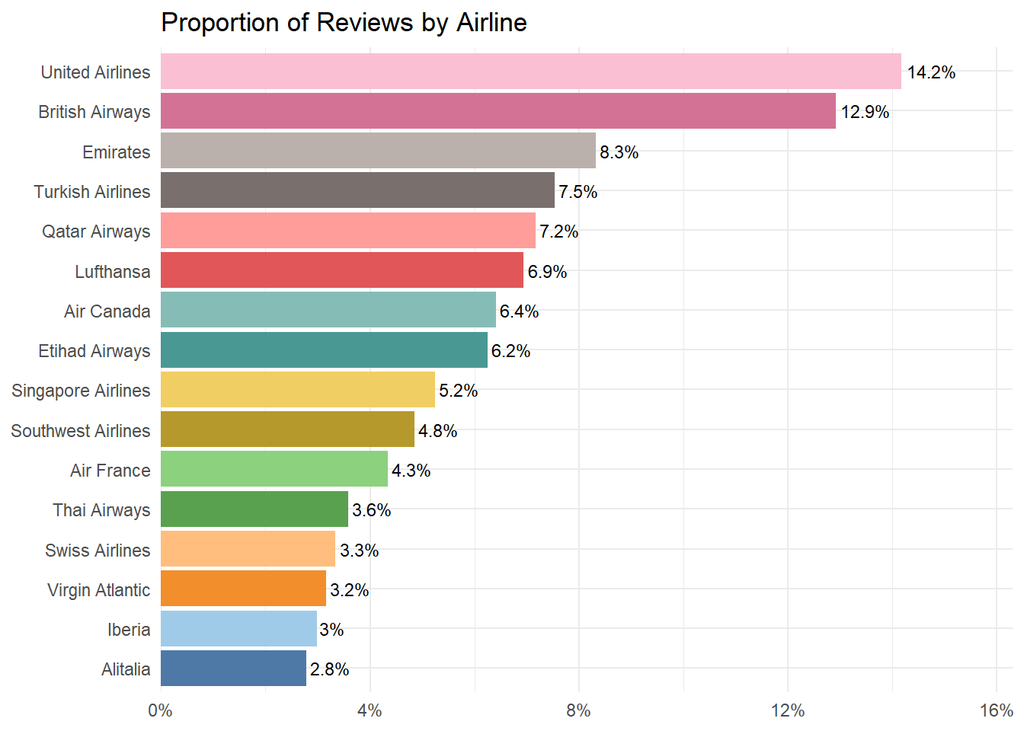

````markdown
```{r}
#| label: bar-plot-review-percent
# Bar chart showing the relative share of reviews per airline
#install.packages("ggrepel")
library(ggrepel)

Airline_Reviews_Leviev |>
  count(Airline) |>
  mutate(
    percent = n / sum(n),
    percent_label = paste0(round(percent * 100, 1), "%"),
    Airline = fct_reorder(Airline, percent)
  ) |>
  ggplot(aes(x = Airline, y = percent, fill = Airline)) +
  geom_col(show.legend = FALSE) +
  coord_flip() +
  geom_text(
    aes(label = percent_label),
    hjust = -0.1,
    size = 3
  ) +
  scale_y_continuous(
    labels = scales::percent,
    expand = expansion(mult = c(0, 0.15))
  ) +
  labs(title = "Proportion of Reviews by Airline", x = NULL, y = NULL) +
  scale_fill_tableau(palette = "Tableau 20") +
  theme_minimal()
```
````

## 2.2 Overall rating by Airlines

To further understand how satisfied passengers are and to ensure that we equally base our analysis on positive and negative reviews, let us rely on the **overall rating score**, each review comes with. The following code allows us to inspect boxplots for the overall rating per airline.

We use again ggplot together with dplyr (included in the package tidyverse) to prepare the boxplot graph as shown in Figure 7-2.

In addition, we use `RColorbrewer` and `ggthemes` to allow us to use a non-standard color representation that matches the color-coding of other popular data visualization tools such as Tableau.

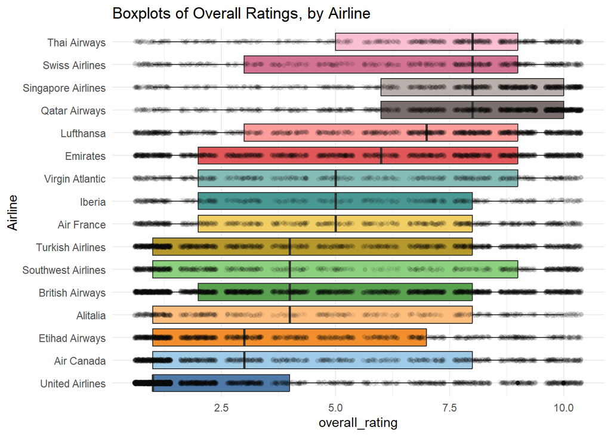

````markdown
```{r}
#| label: box-plot-rating
Airline_Reviews_Leviev |>
  mutate(Airline = fct_reorder(Airline, overall_rating)) |>
  ggplot(aes(x = Airline, y = overall_rating, fill = Airline)) +
  geom_boxplot() +
  geom_jitter(width = 0.05, alpha = 0.05) +
  scale_fill_tableau(palette = "Tableau 20") +
  coord_flip() +
  ggtitle("Boxplots of Overall Ratings, by Airline") +
  theme_minimal() +
  theme(legend.position = "none")
```
````

**Note**Question 1.**:**

*Look at the different boxplots of the airlines and compare them.* What does the size of the box (how wide or narrow the box is) tell you?

To better understand and inspect the mean ratings we can also rely on a barchart plot which we obtain with the following code. Note that we use reorder to have the barplots in ascending order.

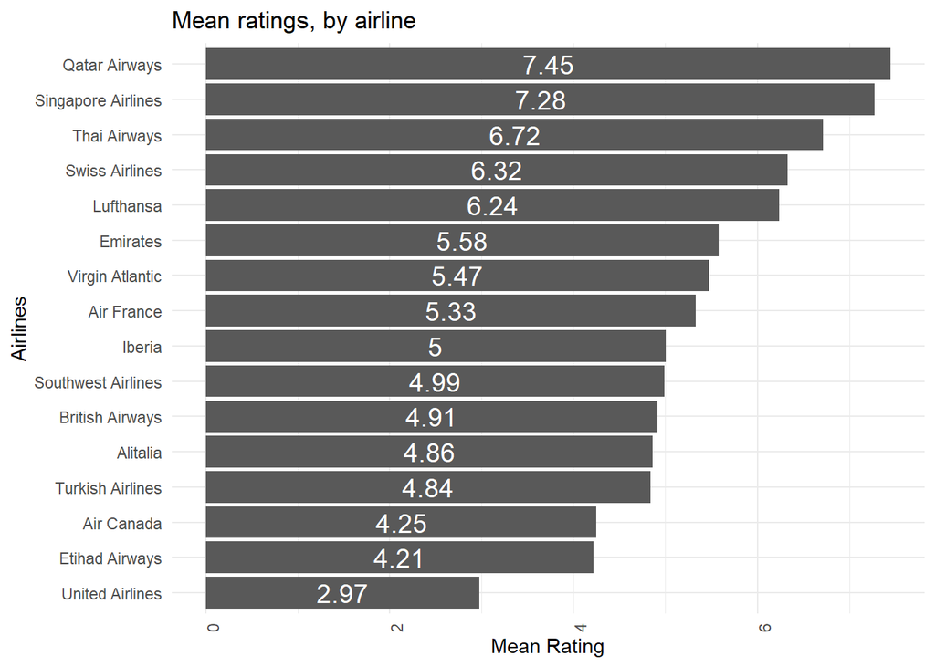

```r
meanrating.airline = Airline_Reviews_Leviev |>
  group_by(Airline) |>
  summarise(MeanRating = mean(overall_rating, na.rm = TRUE))

meanrating.airline |>
  ggplot(aes(reorder(Airline, MeanRating), MeanRating)) +
  geom_col() +
  xlab("Airlines") +
  ylab("Mean Rating") +
  ggtitle("Mean ratings, by airline") +
  geom_text(
    aes(label = round(MeanRating, digits = 2)),
    size = 5,
    colour = "white",
    position = position_stack(vjust = 0.5)
  ) +
  coord_flip() +
  theme_minimal() +
  theme(axis.text.x = element_text(angle = 90))
```

Both, the boxplots as well as the bar chart, indicate that we have enough variation in our reviews to continue with our analysis. We can thus start with trying to understand how favorably (or unfavorably) passengers write about an airline.

# 3 Sentiment Analysis

## 3.1 Introduction

Two categories of methods exist.

- Top-Down Sentiment Classifiers:
  - Top-Down Sentiment Classifiers work by analyzing text at a high level, using pre-defined sentiment lexicons to classify the overall sentiment of a text.
  - Uses **bag-of-words** approach to analyze text at a high level, using pre-defined sentiment lexicons to classify the overall sentiment of a text.
- Bottom-Up Sentiment Classifiers
  - Bottom-Up Sentiment Classifiers work by analyzing text at a granular level, breaking down the text into individual words or phrases and then aggregating sentiment scores to determine the overall sentiment.

Let us first see how **Top-Down Sentiment Classifiers** work and how we can extract emotion and sentiment information with the help of the *NRC dictionary*.

In R the **EmoLex NRC dictionary** is implemented in various packages. We recommend to use the `tidytext` package, as it allows for best text handling and has furthermore been shown to be superior in speed and computational needs. After loading the package, we can now use the inbuilt `EmoLex NRC` function to gain a first understanding of which airlines face which types of emotions, by looking at the mean emotion levels per airline. We start, with the following code.

## 3.2 Unnesting target text

```r
Airline_Reviews_Leviev$ReviewNumb = 1:24391
AirlineReviews_Words <- Airline_Reviews_Leviev |>
  mutate(ReviewNumb = 1:24391) |>
  unnest_tokens(word, review_text)

AirlineReviews_Words |>
  select(ReviewNumb, word)
```

| ReviewNumb | word |
| --- | --- |
| 1 | very |
| 1 | bad |
| 1 | service |
| 1 | and |
| 1 | customer |
| 1 | support |
| 1 | they |
| 1 | changed |
| 1 | my |
| 1 | flight |

[output cut: 9990 more lines]

Looking at the created AirlineReviews_Words dataframe, you will quickly realize that added now two more columns to the initial frame. ReviewNumb simply assigns a number from 1 to 24391 to each review. With unnest_tokens with additionally now created for each word in a review a separate row. Screening through the dataframe you can see that we now have for review 1 93 rows, which corresponds to the total number of words written in review 1. This also explains, why the dataframe now consists of 3,580,738 rows, as this is the number of reviews multiplied by the number of words used in total. If you look at the different words in the word column, you will quickly realize that the majority of words used here, do not have a real emotional meaning. E.g. we can not infer anything from words such as “and”, “the”, or “that”. These words are however frequently applied and thus complicate sentiment measurement, as our computer needs to also read through them, while trying to find words from the emotion lists. To help, we can simply delete all words, which do not provide too much meaning with the help of another dictionary. Words without much meaning potential are commonly referred to as **stopwords**. There are many stopword lists, one can use (or adapt by adding other words, one does not want to have included). In tidytext, we can achieve this by simply applying the following command.

## 3.3 Removing stopwords

```r
AirlineReviews_Words <- AirlineReviews_Words |>
  anti_join(stop_words, by = "word")
```

Via anti_join we simply tell R to look up all words in the stop_words list and drop rows, which contain a stopword from the dataframe. Looking into our environment, we can now see that the dataframe substantially shrank, and now “only” incorporates 1,476,635 rows. This will make it now also much easier for our computer to count the emotion words.

## 3.4 Extracting Sentiment with NRC Dictionary

```r
#install.packages("textdata")
library(textdata)
nrc <- lexicon_nrc(dir = getwd())

AirlineReviews_Sentiment <- AirlineReviews_Words |>
  inner_join(nrc) |>
  count(Airline, index = ReviewNumb, sentiment) |>
  pivot_wider(names_from = sentiment, values_from = n, values_fill = 0)
AirlineReviews_Sentiment
```

| Airline | index | anger | anticipation | disgust | fear | joy | negative | positive | sadness | trust | surprise |
| --- | --- | --- | --- | --- | --- | --- | --- | --- | --- | --- | --- |
| Air Canada | 1 | 2 | 1 | 2 | 4 | 1 | 4 | 7 | 3 | 3 | 0 |
| Air Canada | 2 | 3 | 3 | 0 | 1 | 3 | 2 | 6 | 2 | 3 | 2 |
| Air Canada | 3 | 1 | 2 | 0 | 0 | 4 | 0 | 10 | 1 | 6 | 1 |
| Air Canada | 4 | 6 | 8 | 5 | 7 | 8 | 14 | 21 | 9 | 13 | 2 |
| Air Canada | 5 | 2 | 5 | 1 | 3 | 0 | 5 | 6 | 5 | 4 | 0 |
| Air Canada | 6 | 1 | 1 | 0 | 1 | 1 | 3 | 4 | 2 | 4 | 1 |
| Air Canada | 7 | 0 | 1 | 0 | 0 | 0 | 2 | 3 | 0 | 1 | 0 |
| Air Canada | 8 | 2 | 2 | 1 | 2 | 0 | 8 | 3 | 3 | 0 | 1 |
| Air Canada | 9 | 0 | 4 | 1 | 5 | 3 | 2 | 9 | 1 | 4 | 3 |
| Air Canada | 10 | 1 | 0 | 1 | 0 | 0 | 2 | 0 | 1 | 0 | 0 |

[output cut: 9990 more lines]

> The resulting data frame now shows how many times a word from each emotion category appears in each review. We can take this information and now calculate the airline-specific mean emotion values.

## 3.5 Mean Emotion Value per Airline

````markdown
```{r}
#| label: mean-emotion-value
AirlineReviews_Sentiment |> glimpse()

AirlineReviews_Sentiment_Means = AirlineReviews_Sentiment |>
  group_by(Airline) |>
  summarise(
    MeanAnger = mean(anger),
    MeanDisgust = mean(disgust),
    MeanFear = mean(fear),
    MeanSadness = mean(sadness),
    MeanNegative = mean(negative),
    MeanAnticipation = mean(anticipation),
    MeanSurprise = mean(surprise),
    MeanTrust = mean(trust),
    MeanJoy = mean(joy),
    MeanPositive = mean(positive)
  ) |>
  mutate(MeanSentiment = MeanPositive - MeanNegative)

AirlineReviews_Sentiment_Means |> glimpse()
```
````

```
Rows: 24,377
Columns: 12
$ Airline      <chr> "Air Canada", "Air Canada", "Air Canada", "Air Canada", "…
$ index        <int> 1, 2, 3, 4, 5, 6, 7, 8, 9, 10, 11, 12, 13, 14, 15, 16, 17…
$ anger        <int> 2, 3, 1, 6, 2, 1, 0, 2, 0, 1, 3, 0, 4, 0, 0, 0, 1, 0, 1, …
$ anticipation <int> 1, 3, 2, 8, 5, 1, 1, 2, 4, 0, 1, 0, 6, 0, 4, 3, 4, 3, 1, …
$ disgust      <int> 2, 0, 0, 5, 1, 0, 0, 1, 1, 1, 2, 0, 0, 0, 0, 0, 0, 1, 1, …
$ fear         <int> 4, 1, 0, 7, 3, 1, 0, 2, 5, 0, 2, 0, 0, 0, 1, 1, 1, 4, 2, …
$ joy          <int> 1, 3, 4, 8, 0, 1, 0, 0, 3, 0, 1, 2, 4, 2, 7, 0, 1, 1, 0, …
$ negative     <int> 4, 2, 0, 14, 5, 3, 2, 8, 2, 2, 5, 0, 4, 4, 1, 1, 1, 3, 5,…
$ positive     <int> 7, 6, 10, 21, 6, 4, 3, 3, 9, 0, 3, 6, 5, 2, 10, 1, 4, 3, …
$ sadness      <int> 3, 2, 1, 9, 5, 2, 0, 3, 1, 1, 4, 0, 0, 2, 0, 1, 0, 1, 2, …
$ trust        <int> 3, 3, 6, 13, 4, 4, 1, 0, 4, 0, 2, 1, 5, 1, 9, 1, 4, 2, 2,…
$ surprise     <int> 0, 2, 1, 2, 0, 1, 0, 1, 3, 0, 3, 0, 4, 2, 1, 1, 0, 1, 0, …
Rows: 16
Columns: 12
$ Airline          <chr> "Air Canada", "Air France", "Alitalia", "British Airw…
$ MeanAnger        <dbl> 1.329923, 1.263456, 1.235641, 1.535578, 1.354998, 1.5…
$ MeanDisgust      <dbl> 1.0613811, 0.9575071, 1.1443299, 1.2989199, 1.1230921…
$ MeanFear         <dbl> 1.684783, 1.513692, 1.490427, 1.832910, 1.667159, 1.8…
$ MeanSadness      <dbl> 1.968670, 1.852691, 1.833579, 2.194727, 1.973904, 2.2…
$ MeanNegative     <dbl> 3.821611, 3.465534, 3.449190, 4.519377, 3.902019, 4.3…
$ MeanAnticipation <dbl> 3.347826, 2.985836, 2.870398, 3.428844, 3.557361, 3.5…
$ MeanSurprise     <dbl> 1.2883632, 1.1095373, 1.1178203, 1.2728717, 1.3111768…
$ MeanTrust        <dbl> 4.676471, 4.728045, 4.310751, 5.709022, 5.568193, 5.3…
$ MeanJoy          <dbl> 2.452685, 2.711048, 2.399116, 3.080051, 3.288528, 3.0…
$ MeanPositive     <dbl> 6.242327, 6.163362, 5.559647, 7.510483, 7.157065, 6.9…
$ MeanSentiment    <dbl> 2.420716, 2.697828, 2.110457, 2.991105, 3.255047, 2.6…
```

## 3.6 Plotting Mean Sentiments

Subsequently, we can now take this data frame to plot the values for each airline. To ensure a good overview, we can also split the frame into three new frames, for the positive and the negative emotions, as well as for the general sentiment scores.

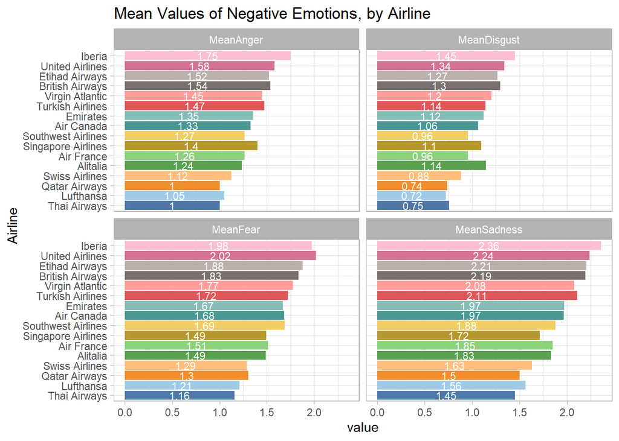

```r
# Negative sentiments

AirlineReviews_NegMeansWide <- AirlineReviews_Sentiment_Means |>
  select(Airline, MeanAnger, MeanDisgust, MeanFear, MeanSadness) |>
  gather(key = "variable", value = "value", -Airline)


AirlineReviews_NegMeansWide |>
  mutate(Airline = fct_reorder(Airline, value)) |>
  ggplot(aes(x = Airline, y = value, fill = Airline)) +
  geom_col() +
  #geom_jitter(width = 0.05, alpha = 0.05) +
  scale_fill_tableau(palette = "Tableau 20") +
  geom_text(
    aes(label = round(value, digits = 2)),
    size = 3,
    colour = "white",
    position = position_stack(vjust = 0.5)
  ) +
  coord_flip() +
  theme(axis.text.x = element_text(angle = 90)) +
  facet_wrap(~variable, ncol = 2) +
  ggtitle("Mean Values of Negative Emotions, by Airline") +
  theme_light() +
  theme(legend.position = "none")
```

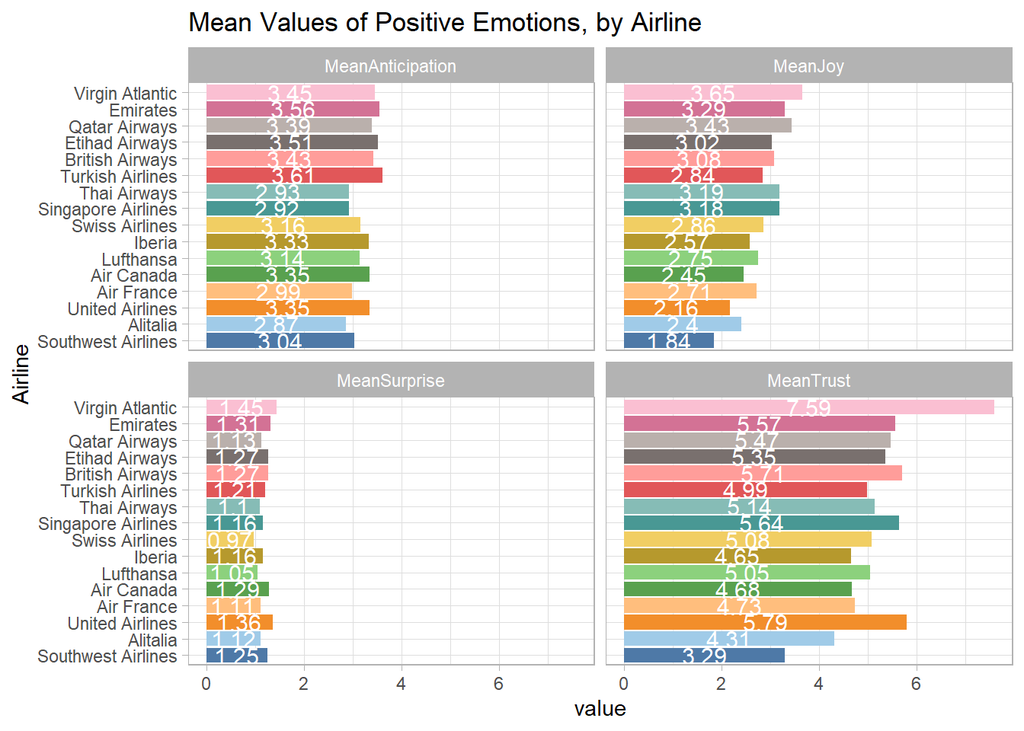

```r
# Positive Sentiments

AirlineReviews_PosMeansWide <- AirlineReviews_Sentiment_Means |>
  select(Airline, MeanJoy, MeanAnticipation, MeanSurprise, MeanTrust) |>
  gather(key = "variable", value = "value", -Airline)

AirlineReviews_PosMeansWide |>
  mutate(Airline = fct_reorder(Airline, value)) |>
  ggplot(aes(x = Airline, y = value, fill = Airline)) +
  scale_fill_tableau(palette = "Tableau 20") +
  geom_col() +
  #geom_jitter(width = 0.05, alpha = 0.05) +
  geom_text(
    aes(label = round(value, digits = 2)),
    size = 4,
    colour = "white",
    position = position_stack(vjust = 0.5)
  ) +
  coord_flip() +
  theme(axis.text.x = element_text(angle = 90)) +
  facet_wrap(~variable, ncol = 2) +
  ggtitle("Mean Values of Positive Emotions, by Airline") +
  theme_light() +
  theme(legend.position = "none")
```

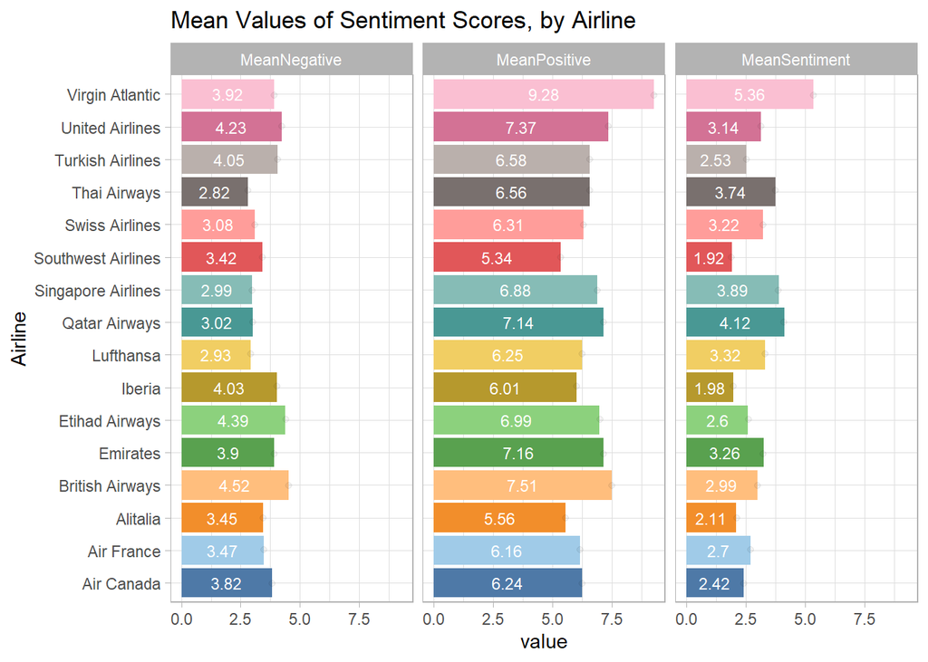

```r
# Mean General Sentiment

AirlineReviews_SentimentMeansWide <- AirlineReviews_Sentiment_Means |>
  select(Airline, MeanPositive, MeanNegative, MeanSentiment) |>
  gather(key = "variable", value = "value", -Airline)

AirlineReviews_SentimentMeansWide |>
  ggplot(aes(x = Airline, y = value, fill = Airline)) +
  scale_fill_tableau(palette = "Tableau 20") +
  geom_col() +
  geom_jitter(width = 0.05, alpha = 0.05) +
  geom_text(
    aes(label = round(value, digits = 2)),
    size = 3,
    colour = "white",
    position = position_stack(vjust = 0.5)
  ) +
  coord_flip() +
  theme(axis.text.x = element_text(angle = 90)) +
  facet_wrap(~variable, ncol = 3) +
  ggtitle("Mean Values of Sentiment Scores, by Airline") +
  theme_light() +
  theme(legend.position = "none")
```

## 3.7 Calculating Emotion Distances

We can also use the emotion information to see how different airlines are from each other. Do you remember the concept of the Euclidean distance, which we discussed in the STP and clustering chapter? We can simply calculate the distance across all airlines based on the mean emotions. We can subsequently use a method called **multidimensional scaling (MDS)** to plot the airlines in a 2-dimensional space, based on the Euclidean distances we just calculated.

```r
Airlines_MeanEmotions = AirlineReviews_Sentiment_Means[, 1:10]

EmotionDistance_Airlines = as.matrix(dist(Airlines_MeanEmotions))
rownames(EmotionDistance_Airlines) <- AirlineReviews_Sentiment_Means$Airline
```

## 3.8 Plotting Airlines in Two-Dimensional Space

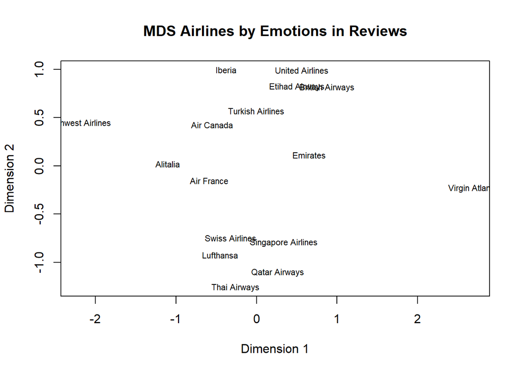

````markdown
```{r}
#| label: plot-emotional-distance
MDS_Emotions <- cmdscale(EmotionDistance_Airlines, eig = TRUE, k = 2) #Classical multidimensional scaling (MDS)

x <- MDS_Emotions$points[, 1]
y <- MDS_Emotions$points[, 2]

plot(
  x,
  y,
  xlab = "Dimension 1",
  ylab = "Dimension 2",
  main = "MDS Airlines by Emotions in Reviews",
  type = "n"
)

text(x, y, labels = row.names(EmotionDistance_Airlines), cex = .7) # text(): Add Text to a Plot
```
````

**Note**Question 2**:**

Looking at the different groups of airlines in the plot, what do you think does it mean if an airline is more on the bottom? What does it mean if an airline is more on the right than on the left hand side of the plot?

# 4 Top-Down vs. Bottom-Up Analysis

Here is a comprehensive comparison of top-down and bottom-up analysis in text mining:

## 4.1 Core Philosophy

|  | Top-Down | Bottom-Up |
| --- | --- | --- |
| Starting point | Theory or hypothesis | Raw text |
| Direction | Theory → Data | Data → Theory |
| Goal | Confirm or reject assumptions | Discover unknown patterns |
| Researcher role | Defines categories in advance | Lets data speak for itself |

## 4.2 Bottom-Up vs Top-Down Summary

|  | Bottom-Up | Top-Down |
| --- | --- | --- |
| Starting point | Raw text | Hypothesis |
| Approach | Exploratory | Confirmatory |
| Outcome | Discover unknown patterns | Test known assumptions |
| Techniques | LDA, word frequency, n-grams | Sentiment classification, keyword search |
| Risk | Findings may be hard to interpret | May miss unexpected patterns |
| Best for | Early exploration, unknown data | Testing specific research questions |

## 4.3 How Each Package Supports Both Approaches

| Package | Bottom-Up Use | Top-Down Use |
| --- | --- | --- |
| `tm` | Word frequency, DTM exploration | Predefined keyword search, classification |
| `tidytext` | N-gram discovery, TF-IDF exploration | Sentiment scoring with predefined lexicons |
| `text2vec` | Vocabulary exploration, topic modeling | ML classification like your `glmnet` model |
| `quanteda` | Corpus statistics, keyword discovery | Dictionary-based analysis, hypothesis testing |

## 4.4 Common Techniques

### 4.4.1 Top-Down Techniques:

| Technique | Purpose |
| --- | --- |
| Sentiment classification | Test if reviews are positive/negative |
| Keyword search | Find predefined terms |
| Dictionary-based analysis | Score against predefined word lists |
| Supervised ML (glmnet, SVM) | Classify into predefined categories |
| VADER | Score sentiment using fixed rules |

### 4.4.2 Bottom-Up Techniques:

| Technique | Purpose |
| --- | --- |
| Word frequency analysis | Discover dominant themes |
| TF-IDF | Find distinctive words per group |
| Topic modeling (LDA) | Uncover hidden themes |
| N-gram analysis | Discover meaningful phrases |
| Word associations | Find co-occurring words |
| Clustering | Group similar documents |

## 4.5 When to Use Each

| Situation | Recommended Approach |
| --- | --- |
| New, unfamiliar dataset | Bottom-Up first |
| Testing a specific business question | Top-Down |
| Exploring customer feedback broadly | Bottom-Up |
| Comparing sentiment across groups | Top-Down |
| Early stages of a research project | Bottom-Up |
| Reporting to stakeholders with specific KPIs | Top-Down |
| Looking for unexpected insights | Bottom-Up |
| Replicating a previous study | Top-Down |

# 5 Rule-Based Top-Down Analysis

## 5.1 Weaknesses

While basic dictionaries such as `LIWC` and `NRC` provide a quick and reliable way to capture words related to different forms and levels of sentiment, they often face the problem that they *do not take the context in which a word occurs into account*.

- **Ignore negation**
  - This can quickly become an issue, if we for example think about the following example.
  - “*I did not like the airline there was no good service and no one cared about us*”
  - If we **ignore the negation**, the review actually consists of several words which are commonly assigned to a positive sentiment such as like, good, and care. Many dictionaries would thus come to the wrong conclusion, by simply counting the occurrence of words, which belong to a positive sentiment category.
- **Ambiguous**
  - Similarly, reviews may be **ambiguous** with different types of sentiment being assigned to two different entities like displayed in the following example:
    - “*It was a shitty holiday with a lot of rain and a bad hotel, but Alitalia was great and we love the service.*”
    - Here the negative sentiment only targets the weather and the hotel, but does explicitly spare the corresponding airline.
    - Simply counting again, the occurrence of words, does not help, as the total number of negative sentiment words is twice the number of positive words.
- **Strength of emotion**
  - Furthermore, the way people write, may also indicate something about the **strength of emotion** involved. Take the following two reviews:
    - “I love Allitalia” and “I LOVE AlIitalia!!!!”
    - You will certainly agree, that the latter expresses more emotion than the first one, as it is written in caps and the love for Allitalia is further underlined by four exclamation marks at the end of the sentence.
  - Again, simply counting the occurrence of positive words, would lead to a wrong result, as both reviews only consist of one positive word (love).
- **New vocabulary**
  - At last, we also witness that digital communication is changing and that consumers adapt their linguistic styles.
  - Often emotions are not only expressed by words, but also by symbols.
    - Think about **emojis, emoticons** (i.e. ;-)) or common abbreviations such as lol (laughing out loud) or rofl (rolling on floor laughing), which made their way into our everyday online conversations.
  - Most established dictionaries do not yet list these new terms and will thus similarly ignore these.

## 5.2 VADER

- Stands for **Valence Aware Dictionary and sEntiment Reasoner**. It is a rule-based sentiment analysis tool specifically designed for **social media and short texts**, though it works well on other text types too.
- **Key Characteristics**

  VADER is different from machine learning approaches like your `glmnet` classifier in that it requires **no training data** — it uses a pre-built dictionary of words with sentiment scores.
- **VADER** is a rule-based dictionary, which means, it does take context into account and controls if a word stands together with a negation, or if a sentiment is enforced by e.g. exclamation marks or being written in caps (Hutto and Gilbert 2014).
- While VADER was initially developed for Python, there is now a package available, that allows us to use VADER also in R.
- Given the rule implementation, the benefit of accounting for context, comes of course at a cost: time.
  - Applying VADER to larger sets of reviews of comments, will **consume substantially more time** than for example NRC.
- Still, often the waiting time is worth the effort.
- Let us now see how well VADER performs. We first build vectors with our special sentences.

### 5.2.1 How It Works

#### 5.2.1.1 1. Sentiment Lexicon

VADER has a dictionary of over 7,500 words, each manually rated on a scale from **-4 (most negative) to +4 (most positive)**:

| Word | Score |
| --- | --- |
| “excellent” | +3.0 |
| “good” | +1.9 |
| “bad” | -2.5 |
| “terrible” | -3.4 |
| “ok” | +0.9 |

#### 5.2.1.2 2. Four Output Scores

For any piece of text, VADER returns four scores:

| Score | Meaning |
| --- | --- |
| `pos` | Proportion of text that is positive (0 to 1) |
| `neg` | Proportion of text that is negative (0 to 1) |
| `neu` | Proportion of text that is neutral (0 to 1) |
| `compound` | Overall sentiment score from **-1 (most negative) to +1 (most positive)** |

The **compound score** is the most commonly used — a single summary score for the whole text.

### 5.2.2 Compound Score Interpretation

| Compound Score | Sentiment |
| --- | --- |
| ≥ 0.05 | Positive |
| ≤ -0.05 | Negative |
| Between -0.05 and 0.05 | Neutral |

### 5.2.3 What Makes VADER Special

Unlike simple word-counting approaches, VADER understands several linguistic nuances:

#### 5.2.3.1 Capitalization

```
"good flight"   → lower sentiment "GOOD flight"   → higher sentiment (emphasis)
```

#### 5.2.3.2 Punctuation

```
"great flight"    → positive "great flight!!!" → more positive (exclamation adds intensity)
```

#### 5.2.3.3 Negation

```
"good"     → positive "not good" → negative (negation is handled)
```

#### 5.2.3.4 Degree Modifiers

```
"good"          → baseline positive "very good"     → more positive "extremely good"→ even more positive "barely good"   → less positive
```

#### 5.2.3.5 Slang and Emoticons

```
"gr8"  → recognized as positive ":-)"  → recognized as positive ":-("  → recognized as negative
```

### 5.2.4 Typical Procedure in R

VADER is available through the `vader` package:

```r
library(vader)

# Single text
get_vader("The flight was absolutely GREAT!!!")

# On a dataframe of reviews
reviews <- reviews |>
  mutate(vader_score = vader_df(text)$compound)

# Classify sentiment using compound score
reviews <- reviews |>
  mutate(
    sentiment = case_when(
      vader_score >= 0.05  ~ "Positive",
      vader_score <= -0.05 ~ "Negative",
      TRUE                 ~ "Neutral"
    )
  )
```

### 5.2.5 VADER vs Machine Learning

[output not shown]

### 5.2.6 When to Use VADER

VADER is a good choice when you have **no labelled training data**, are working with **social media text**, need a **quick baseline** before building a full ML model, or want a **simple interpretable** approach. For domain-specific tasks like airline reviews where you have labelled data, a trained model like `glmnet` classifier will generally outperform VADER.

### 5.2.7 Data

```r
Clear_Review = "It was a shitty holiday with a lot of rain and a bad airline"
Negations_Review = "I did not like the airline there was no good service and no one cared about us."

Ambigious_Review = "It was a shitty holiday with a lot of rain and a bad hotel, but Alitalia was great and we love the service."

Symbolic_Review = "Alitalia is my <3!!!! Always :-D"

NoExclamation_Review = "I love Alitalia"

Exclamation_Review = "I LOVE Alitalia!!!!"
```

### 5.2.8 Calculate Vader Sentiments

We can now use the following code to calculate the sentiment of each sentence.

```r
library(vader)

# Use get_vader() to calculate the valence of a single text document.
Sentiment_Clear_Review = get_vader(
  Clear_Review,
  incl_nt = T, # includes contractions e.g., yesn't
  neu_set = T, # count neutral words
  rm_qm = F #remove quotation mark
)

Sentiment_Negations_Review = get_vader(
  Negations_Review,
  incl_nt = T,
  neu_set = T,
  rm_qm = F
)

Sentiment_Ambigious_Review = get_vader(
  Ambigious_Review,
  incl_nt = T,
  neu_set = T,
  rm_qm = F
)

Sentiment_Symbolic_Review = get_vader(
  Symbolic_Review,
  incl_nt = T,
  neu_set = T,
  rm_qm = F
)

Sentiment_NoExclamation = get_vader(
  NoExclamation_Review,
  incl_nt = T,
  neu_set = T,
  rm_qm = F
)

Sentiment_Exclamation = get_vader(
  Exclamation_Review,
  incl_nt = T,
  neu_set = T,
  rm_qm = F
)
```

### 5.2.9 Forming Data Frame

```r
VADER = bind_rows(
  Sentiment_Clear_Review,
  Sentiment_Negations_Review,
  Sentiment_Ambigious_Review,
  Sentiment_Symbolic_Review,
  Sentiment_NoExclamation,
  Sentiment_Exclamation
)

Text_vader = c(
  Clear_Review,
  Negations_Review,
  Ambigious_Review,
  Symbolic_Review,
  NoExclamation_Review,
  Exclamation_Review
)

VADER$Text = Text_vader
head(VADER)
```

| word_scores | compound | pos | neu | neg | but_count | Text |
| --- | --- | --- | --- | --- | --- | --- |
| {0, 0, 0, -2.6, 1.7, 0, 0, 0, 0, 0, 0, 0, -2.5, 0} | -0.66 | 0.13 | 0.529 | 0.341 | 0 | It was a shitty holiday with a lot of rain and a bad airline |
| {0, 0, 0, -1.11, 0, 0, 0, 0, 0, -1.406, 0, 0, 0, 0, -1.332, 0, 0} | -0.705 | 0 | 0.672 | 0.328 | 0 | I did not like the airline there was no good service and no one cared about us. |
| {0, 0, 0, -1.3, 0.85, 0, 0, 0, 0, 0, 0, 0, -1.25, 0, 0, 0, 0, 4.65, 0, 0, 4.8, 0, 0} | 0.895 | 0.371 | 0.502 | 0.127 | 1 | It was a shitty holiday with a lot of rain and a bad hotel, but Alitalia was great and we love the service. |
| {0, 0, 0, 0, 0, 2.3} | 0.667 | 0.472 | 0.528 | 0 | 0 | Alitalia is my <3!!!! Always :-D |
| {0, 3.2, 0} | 0.637 | 0.677 | 0.323 | 0 | 0 | I love Alitalia |
| {0, 3.933, 0} | 0.796 | 0.753 | 0.247 | 0 | 0 | I LOVE Alitalia!!!! |

# 6 Bottom-Up Analysis

## 6.1 Introduction

While Top-Down sentiment analysis relies on *pre-curated lists* which commonly originate from previous research studies and are the result of thorough qualitative research work, bottom-up sentiment analysis is trying to “build” own dictionaries with the help of **supervised machine learning**.

Here, we use *textual data*, where we know already the sentiment, to infer probabilities that the occurrence of words (or word combinations) represent a positive or negative sentiment (or any other category we are interested in such as satisfaction, recommendation, disgust, etc.).

- **Training Data**
  - The textual data we infer the probabilities from is commonly referred to as training data.
  - Training data can be obtained from various sources. For example, one may use human coders to classify a set of texts into the categories of interest (i.e. positive or negative sentiment) and use these texts as training data.

## 6.2 Building Training a Dataset

Given that we have already *overall rating scores*, we can follow the latter approach and split our own review data set in two data sets, containing only **negative** and **positive** reviews.

```r
Negative_Reviews = Airline_Reviews_Leviev |> filter(overall_rating < 2)
Positive_Reviews = Airline_Reviews_Leviev |> filter(overall_rating > 8)

set.seed(123)

Negative_Reviews_Sample = sample_n(Negative_Reviews, 2000)
Positive_Reviews_Sample = sample_n(Positive_Reviews, 2000)

BottomUpDF = data.frame(
  sentiment = "positive",
  text = Positive_Reviews_Sample$title
)
BottomUpDF = rbind(
  BottomUpDF,
  data.frame(sentiment = "negative", text = Negative_Reviews_Sample$title)
)

str(BottomUpDF)
```

```
'data.frame':   4000 obs. of  2 variables:
 $ sentiment: chr  "positive" "positive" "positive" "positive" ...
 $ text     : chr  "\"great meal\"" "\"It was phenomenal\"" "\"crew are nice and attentive\"" "Virgin Atlantic customer review" ...
```

**TipHow to build a training dataset**

Once we have the sets of positive and negative reviews, we can randomly extract 2000 positive and 2000 negative reviews, which will then serve as our training data. Of course, you can use more (or less) data, according to the computational power at your hand. Another trick here to save computational power and to be not too overdemanding to our laptops is to use only the title of the reviews and not the whole review text, as we can assume that the title will perfectly summarize the review and thus contain the main sentiment.

Once we randomly selected the reviews, we bind them together in the dataframe BottomUpDF, that now contains the titles as well as the information if the title origins from the “positive” or “negative” sentiment set.

## 6.3 Cleaning and Preparing the Dataset

We can then continue to further prepare the textual information and to make life a bit easier for our computers, by transferring all text to *lower case* (otherwise the algorithm would treat airline and Airline as two different words), **removing any punctuation** as elements such as commas, etc. do not provide much meaning, **clean the corpus from *stopwords***, and *stem* **all words** to their common form, which again helps to remove redundancies in the data and making the set slimmer.

Finally, we can use the `removeSparseTerms` function to identify words, which occur only rarely and which will thus similarly not provide too much information (here we drop words, which only occur in *0.5% of all documents*; feel free to try out other cut-off values).

The resulting dataframe `tSparse` now has for each word included in our training data set a column, and indicates for each document (rows) if a word occurs or not (1/0). Such matrices are commonly referred to as a **Document Term Matrix**.

At last, we use `prop.table` to show us the distribution of positive and negative review titles in our data set. The output indicates that we have a perfectly balanced training data set at our hand that consists of 50% negative and 50% positive review titles.

```r
# tm_map(): Interface to apply transformation functions (also denoted as mappings) to corpora.

corpus = Corpus(VectorSource(BottomUpDF$text))
corpus = tm_map(corpus, PlainTextDocument)
corpus = tm_map(corpus, tolower)
corpus = tm_map(corpus, removePunctuation)
corpus = tm_map(corpus, removeWords, c("cloth", stopwords("english")))
corpus = tm_map(corpus, stemDocument)
frequencies = DocumentTermMatrix(corpus)
sparse = removeSparseTerms(frequencies, 0.995) #0.5%
tSparse = as.data.frame(as.matrix(sparse))
colnames(tSparse) = make.names(colnames(tSparse))
tSparse$sentiment = BottomUpDF$sentiment

str(tSparse)
```

```
'data.frame':   4000 obs. of  87 variables:
 $ great     : num  1 0 0 0 0 0 0 0 0 0 ...
 $ attent    : num  0 0 1 0 0 0 0 0 0 0 ...
 $ crew      : num  0 0 1 0 0 0 0 0 0 0 ...
 $ nice      : num  0 0 1 0 0 0 0 0 0 0 ...
 $ atlant    : num  0 0 0 1 0 0 0 0 0 0 ...
 $ custom    : num  0 0 0 1 1 1 0 0 0 1 ...
 $ review    : num  0 0 0 1 1 1 0 0 0 1 ...
 $ virgin    : num  0 0 0 1 0 0 0 0 0 0 ...
 $ airway    : num  0 0 0 0 1 0 0 0 0 0 ...
 $ qatar     : num  0 0 0 0 1 0 0 0 0 0 ...
 $ lufthansa : num  0 0 0 0 0 1 0 0 0 1 ...
 $ food      : num  0 0 0 0 0 0 1 0 0 0 ...
 $ impress   : num  0 0 0 0 0 0 1 0 0 0 ...
 $ servic    : num  0 0 0 0 0 0 1 0 0 0 ...
```

[output cut: 73 more lines]

```r
prop.table(table(tSparse$sentiment))
```

```
negative positive
     0.5      0.5
```

We can now start with training a basic machine learning model that allows us to determine whether a new review (or any other airline-specific text) is positive or negative.

## 6.4 Split Prepped Training Data

To be able to later assess the quality of our sentiment classifier, we have to again split our training data set into the **“real” training set** and into a **test set**.

The test set will allow us later to determine how accurate our sentiment predictions are, as we can first predict the sentiment with the help of the sentiment classifier and to compare the predictions with the known sentiment.

We rely here on an **80/20 split** but feel free to try out other compositions.

```
'data.frame':   3200 obs. of  87 variables:
 $ great     : num  1 0 0 0 0 0 0 0 0 0 ...
 $ attent    : num  0 0 1 0 0 0 0 0 0 0 ...
 $ crew      : num  0 0 1 0 0 0 0 0 0 0 ...
 $ nice      : num  0 0 1 0 0 0 0 0 0 0 ...
 $ atlant    : num  0 0 0 1 0 0 0 0 0 0 ...
 $ custom    : num  0 0 0 1 1 1 0 0 1 0 ...
 $ review    : num  0 0 0 1 1 1 0 0 1 0 ...
 $ virgin    : num  0 0 0 1 0 0 0 0 0 0 ...
 $ airway    : num  0 0 0 0 1 0 0 0 0 0 ...
 $ qatar     : num  0 0 0 0 1 0 0 0 0 0 ...
 $ lufthansa : num  0 0 0 0 0 1 0 0 1 0 ...
 $ food      : num  0 0 0 0 0 0 0 0 0 0 ...
 $ impress   : num  0 0 0 0 0 0 0 0 0 0 ...
 $ servic    : num  0 0 0 0 0 0 0 0 0 0 ...
```

[output cut: 74 more lines]

## 6.5 Random Forest Model

We can now start with using the trainSparse set to *develop our classifier*. We will rely on a common classification algorithm, called Random Forest. The algorithm will try to infer for each word in our *DTM* the probability that this word occurs in a positive or a negative review title.

## 6.6 Predicting Sentiments

Basically, we now already have the classifier ready. Nevertheless, we need to understand how well it *predicts*. So, we need to go ahead and predict the sentiment of all review titles in our test set to see how many times the model correctly predicts negative and positive titles. We can achieve this with the following code.

```r
predictRF = predict(RF_model, newdata = testSparse)
table(testSparse$sentiment, predictRF)
```

```
          predictRF
           negative positive
  negative      330       70
  positive       76      324
```

**Accuracy** = Number of correctly classified titles / Total number of titles

Accuracy = (330+324)/800 = 0.8175.

So, this means in 81.75% of classifications, our classifier comes to the correct result. This is already a rather good fit. Still, we can do better, as we will see in the next paragraph.

# 7 Vector-Based Bottom-Up Analysis

So far, we relied on the pure occurrence of words in a document to infer the sentiment probabilities. However, we saw before that the context in which a word is embedded also matters. The latest developments such as `Word2Vec` in NLP account for this.

We can access the package and start building our model with the following code.

## 7.1 Splitting Data into Training and Testing Sets

````markdown
```{r}
#| label: text2vec-sentiment-analysis
# Train and Test Data

Negative_Reviews = Airline_Reviews_Leviev |> filter(overall_rating < 2)
Positive_Reviews = Airline_Reviews_Leviev |> filter(overall_rating > 8)

set.seed(123)

Negative_Reviews_Sample = sample_n(Negative_Reviews, 2000)
Positive_Reviews_Sample = sample_n(Positive_Reviews, 2000)

BottomUpDF = data.frame(
  sentiment = "positive",
  text = Positive_Reviews_Sample$title
)
BottomUpDF = rbind(
  BottomUpDF,
  data.frame(sentiment = "negative", text = Negative_Reviews_Sample$title)
)
BottomUpDF$id = 1:4000

index = sample(1:nrow(BottomUpDF), size = .80 * nrow(BottomUpDF))

train = BottomUpDF[index, ]
test = BottomUpDF[-index, ]

str(train)
```
````

```
'data.frame':   3200 obs. of  3 variables:
 $ sentiment: chr  "positive" "positive" "positive" "negative" ...
 $ text     : chr  "\"Cabin crew were amazing\"" "Swiss Intl Air Lines customer review" "\"good and experienced crew\"" "United Airlines customer review" ...
 $ id       : int  98 390 1044 3941 1105 3410 3256 2675 1037 1593 ...
```

Similar to our Random Forrest example we start again by building a training and test data set, that we can use for evaluating the accuracy of our sentiment classifier.

To make things comparable we use the same number of randomly drawn review titles and split again **80/20**. Furthermore, we apply again similar pre-processing steps and lower all words.

## 7.2 Pre-processing

- Overall Flow

```
raw text → tolower → word_tokenizer → vocabulary → vectorizer → DTM
```

```r
# define preprocessing function and tokenization function
prep_fun = tolower
tok_fun = word_tokenizer

# itoken(){text2vec}: Iterators (and parallel iterators) over input objects

# First itoken() Pass — with Preprocessor
it_train = itoken(
  train$text,
  preprocessor = prep_fun,
  tokenizer = tok_fun,
  ids = train$id,
  progressbar = FALSE
)
vocab = create_vocabulary(it_train)

# Manual Tokenization + Second itoken() Pass
train_tokens = tok_fun(prep_fun(train$text))
it_train = itoken(train_tokens, ids = train$id, progressbar = FALSE)

# Build the Vocabulary
vocab = create_vocabulary(it_train)

# Create the Vectorizer:
## Converts the vocabulary into a vectorizer function that knows how to map words to column indices. Think of it as a lookup table that will be applied consistently to both training and test data.
vectorizer = vocab_vectorizer(vocab)
```

**TipDocument-Term Matrix**

The DTM is a sparse matrix (most cells are 0), which `text2vec` handles efficiently, making this pipeline well-suited for large text datasets like airline reviews.

Creates a **Document-Term Matrix** — a sparse matrix where:

- Each **row** is one document (review)
- Each **column** is one word from the vocabulary
- Each **cell** is the word count for that word in that document

For example:

|  | good | flight | delay |
| --- | --- | --- | --- |
| doc1 | 2 | 1 | 0 |
| doc2 | 0 | 1 | 3 |

````markdown
```{r}
#| label: build-dtm-as-features
# Build the Document-Term Matrix (DTM)
dtm_train = create_dtm(it_train, vectorizer)
```
````

## 7.3 Training a model

### 7.3.1 Regularized Regression Model

#### 7.3.1.1 Core Idea

Regular regression (OLS) minimizes the sum of squared residuals. `glmnet` adds a **penalty term** to shrink or zero out coefficients, which helps with:

- **Overfitting** — especially when you have many predictors
- **Variable selection** — Lasso can shrink some coefficients to exactly 0
- **Multicollinearity** — Ridge handles correlated predictors well
- The penalty is controlled by two parameters:

| Parameter | Meaning |
| --- | --- |
| `lambda` (λ) | Overall regularization strength |
| `alpha` (α) | Mix between L1 and L2 (0 = Ridge, 1 = Lasso, 0–1 = Elastic Net) |

#### 7.3.1.2 Regularized Regression Objective Function

All three models minimize a **loss term** plus a **penalty term**:

$$\underbrace{\sum_{i=1}^{n}(y_i - x_i^T\beta)^2}_{\text{Loss (RSS)}} + \underbrace{\lambda \cdot \text{Penalty}(\beta)}_{\text{Regularization}}$$

where $n$ = number of samples, $p$ = number of predictors, $\beta$ = coefficient vector, and $\lambda \geq 0$ controls regularization strength.

##### 7.3.1.2.1 ① Ridge Regression ($\alpha = 0$)

$$\min_{\beta} \sum_{i=1}^{n}(y_i - x_i^T\beta)^2 + \lambda \sum_{j=1}^{p} \beta_j^2$$

- Applies an **L2 penalty** (sum of squared coefficients)
- Shrinks all coefficients toward zero, but never to exactly zero
- Handles multicollinearity well

##### 7.3.1.2.2 ② Lasso Regression ($\alpha = 1$)

$$\min_{\beta} \sum_{i=1}^{n}(y_i - x_i^T\beta)^2 + \lambda \sum_{j=1}^{p} |\beta_j|$$

- Applies an **L1 penalty** (sum of absolute coefficients)
- Can shrink coefficients to **exactly zero** → automatic variable selection
- Produces sparse solutions

##### 7.3.1.2.3 ③ Elastic Net ($0 < \alpha < 1$)

$$\min_{\beta} \sum_{i=1}^{n}(y_i - x_i^T\beta)^2 + \lambda \left[ (1 - \alpha)\sum_{j=1}^{p}\beta_j^2 + \alpha \sum_{j=1}^{p}|\beta_j| \right]$$

- Blends **L1 and L2** penalties, controlled by $\alpha$
- $\alpha = 0$ reduces to Ridge; $\alpha = 1$ reduces to Lasso
- Handles correlated predictors while still allowing sparsity
- Default in `glmnet` (use `cv.glmnet()` to tune both $\lambda$ and $\alpha$)

#### 7.3.1.3 Summary Table

| Model | Penalty | $\alpha$ | Variable Selection |
| --- | --- | --- | --- |
| Ridge | $\lambda \sum \beta_j^2$ | 0 | No |
| Lasso | $\lambda \sum \|\beta_j\|$ | 1 | Yes |
| Elastic Net | $\lambda[(1-\alpha)\sum\beta_j^2 + \alpha\sum\|\beta_j\|]$ | $(0,1)$ | Partial |

#### 7.3.1.4 `glmnet` Package

`glmnet` is a powerful R package for fitting **regularized regression models** — specifically, it fits generalized linear models (GLMs) with **elastic net regularization**, which includes both **Lasso (L1)** and **Ridge (L2)** penalties as special cases.

#### 7.3.1.5 Supported Model Types

- Linear regression (`family = "gaussian"`)
- Logistic regression (`family = "binomial"` or `"multinomial"`)
- Poisson regression (`family = "poisson"`)
- Cox proportional hazards (`family = "cox"`)
- And more

#### 7.3.1.6 Basic Usage

```r
library(glmnet)

# Fit a Lasso model (alpha = 1)
fit <- glmnet(x, y, alpha = 1)

# Use cross-validation to find the best lambda
cv_fit <- cv.glmnet(x, y, alpha = 1)

# Best lambda
best_lambda <- cv_fit$lambda.min

# Predict using best lambda
predict(cv_fit, newx = x_new, s = "lambda.min")
```

> **Note:** `x` must be a **matrix**, not a data frame. Use `model.matrix()` to convert if needed.

#### 7.3.1.7 Key Functions

| Function | Purpose |
| --- | --- |
| `glmnet()` | Fit model over a path of λ values |
| `cv.glmnet()` | Cross-validated λ selection |
| `predict()` | Generate predictions |
| `coef()` | Extract model coefficients |
| `plot()` | Visualize coefficient paths or CV curve |

#### 7.3.1.8 Why Use It?

- Very **fast** — uses coordinate descent algorithm
- Handles **high-dimensional data** (more predictors than observations)
- Built-in **cross-validation** via `cv.glmnet()`
- Widely used in **genomics, finance, NLP**, and other fields

In short, `glmnet` is the go-to tool in R when you need regularized regression for prediction or variable selection.

### 7.3.2 Training Lasso model

> Now we can start with training the model with the following command. We tell the `glmnet` function, where it can find the training data (*dtm_train*) and which variable is the outcome variable of interest (*sentiment*).

The other values in the function are **tuning parameters**, which can be ignored for now. In case you want to go in more detail here, we recommend to consult the vignette of the text2vec package.

```
Call:  cv.glmnet(x = dtm_train, y = train[["sentiment"]], type.measure = "auc",      nfolds = NFOLDS, family = "binomial", alpha = 1, thresh = 0.001,      maxit = 1000)

Measure: AUC

      Lambda Index Measure       SE Nonzero
min 0.002057    43  0.9203 0.003530     721
1se 0.006893    30  0.9169 0.003592     486
[1] 0.002056543
[1] "max AUC = 0.9203"
```

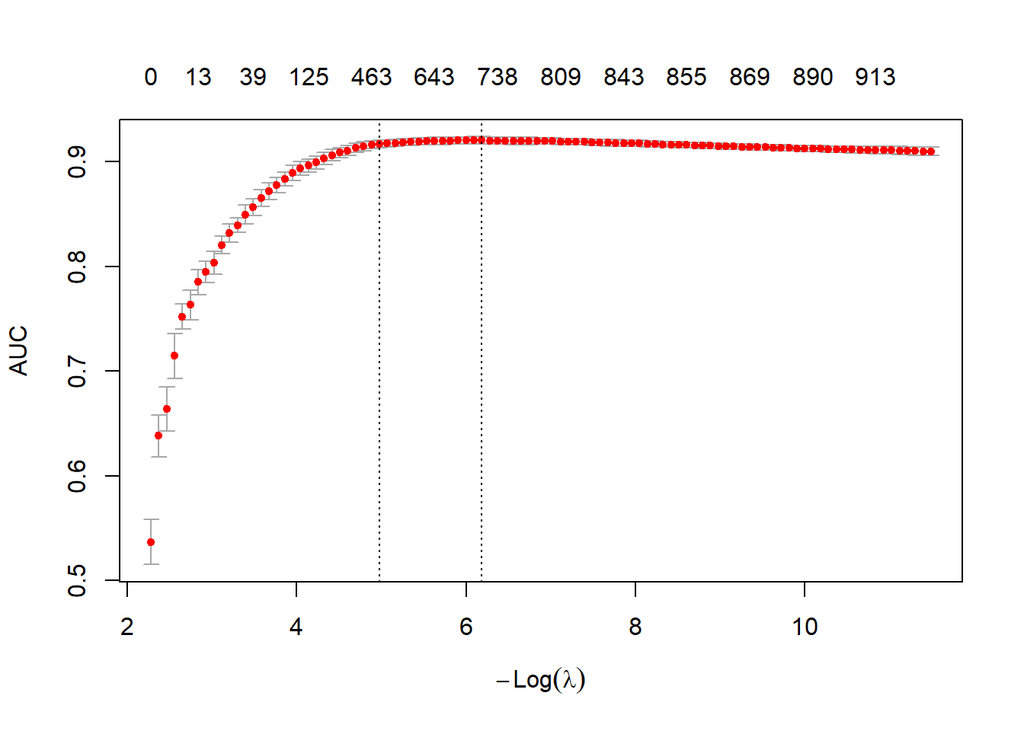

````markdown
```{r}
#| label: training-logistic-regression-lasso
library(glmnet)

NFOLDS = 4
glmnet_classifier = cv.glmnet(
  x = dtm_train,
  y = train[['sentiment']],
  family = 'binomial', # Logistic regression for binary classification
  alpha = 1, # Lasso regularization
  type.measure = "auc", #Uses AUC (Area Under the ROC Curve) for evaluation instead of deviance
  nfolds = NFOLDS, # Number of cross-validation folds
  thresh = 1e-3, # Convergence threshold — stops when improvement is < 0.001
  maxit = 1e3 # Maximum 1000 iterations to prevent infinite loops
)

glmnet_classifier

plot(glmnet_classifier)

glmnet_classifier$lambda.min #lambda with highest AUC

print(paste("max AUC =", round(max(glmnet_classifier$cvm), 4)))
```
````

### 7.3.3 Output Interpretation

```
quCall:  cv.glmnet(x = dtm_train, y = train[["sentiment"]], type.measure = "auc",      nfolds = NFOLDS, family = "binomial", alpha = 1, thresh = 0.001,      maxit = 1000)

Measure: AUC

      Lambda Index Measure       SE Nonzero
min 0.002057    43  0.9203 0.003530     721
1se 0.006893    30  0.9169 0.003592     486

[1] 0.002056543
[1] "max AUC = 0.9203"
```

#### 7.3.3.1 Row 1: `min` — Best Raw Performance

```
Lambda = 0.002057, Index = 43, AUC = 0.9203, SE = 0.003530, Nonzero = 721
```

- This lambda value (0.002057) produced the **highest average AUC of 0.9203** across the 4 folds
- It uses **721 words** (non-zero coefficients) from the vocabulary as predictors
- In other words, 721 words were found useful enough to contribute to the sentiment prediction

#### 7.3.3.2 Row 2: `1se` — Simpler, More Regularized Model

```
Lambda = 0.006893, Index = 30, AUC = 0.9169, SE = 0.003592, Nonzero = 486
```

- This is the **largest lambda** whose AUC is within **1 standard error** of the best AUC (0.9203 - 0.003530 ≈ 0.917)
- It uses only **486 words** — a simpler model with 235 fewer predictors
- The AUC drop is tiny (0.9203 → 0.9169) but the model is meaningfully simpler

#### 7.3.3.3 The SE Column

```
SE = 0.003530
```

- This is the **standard error of the AUC** across the 4 cross-validation folds
- A small SE means the model performance was **consistent** across folds — which is the case here, indicating a stable model

#### 7.3.3.4 Overall Model Quality

| AUC Range | Interpretation |
| --- | --- |
| 0.5 | Random guessing |
| 0.7 – 0.8 | Acceptable |
| 0.8 – 0.9 | Good |
| **0.9+** | **Excellent** ✓ |

#### 7.3.3.5 Which Lambda Should You Choose?

| Choice | Use when… |
| --- | --- |
| `lambda.min` | You want **maximum predictive accuracy** and don’t mind a more complex model |
| `lambda.1se` | You prefer a **simpler, more interpretable** model with minimal accuracy loss |

In practice `lambda.1se` is often recommended as it gives a more parsimonious model — dropping 235 words while only losing 0.003 AUC is a good trade-off.

#### 7.3.3.6 What is AUC?

**AUC** stands for **Area Under the (ROC) Curve**. It is a performance metric for **binary classification models** (e.g., positive vs. negative sentiment).

- **ROC** = Receiver Operating Characteristic curve — a plot of:
  - **True Positive Rate (Sensitivity)** on the Y-axis
  - **False Positive Rate (1 − Specificity)** on the X-axis
- **AUC** = Operatoinally, it is the area underneath that curve, but Conceptually, AUC answers one fundamental question:

  > **“If I randomly pick one positive review and one negative review, what is the probability that my model correctly ranks the positive one higher than the negative one?”**

  An AUC of 0.93 means there is a **93% chance** the model assigns a higher predicted probability to a positive review than to a negative one. It is a measure of **separability** — how well the model can distinguish between the two classes across all possible thresholds.

#### 7.3.3.7 How to Interpret AUC

| AUC Value | Interpretation |
| --- | --- |
| 1.00 | Perfect classifier - curve hugs the top-left corner completely |
| 0.90 – 0.99 | Excellent - large shaded area, strong separation |
| 0.80 – 0.89 | Good |
| 0.70 – 0.79 | Fair |
| 0.60 – 0.69 | Poor |
| 0.50 | Useless - Curve is the diagonal, no better than random guessing |
| < 0.50 | Worse than random |

AUC essentially answers: **“What is the probability that the model ranks a randomly chosen positive case higher than a randomly chosen negative case?”**

#### 7.3.3.8 AUC in Regularized Regression (glmnet)

In `glmnet`, when you run logistic regression (`family = "binomial"`) with cross-validation, you can use AUC as the evaluation metric:

```r
cv_model <- cv.glmnet(
  x,
  y,
  family = "binomial",
  type.measure = "auc", # use AUC instead of deviance
  alpha = 1
)

plot(cv_model) # AUC vs. log(lambda)
cv_model$lambda.min # lambda with highest AUC
```

##### 7.3.3.8.1 Confusion Matrix

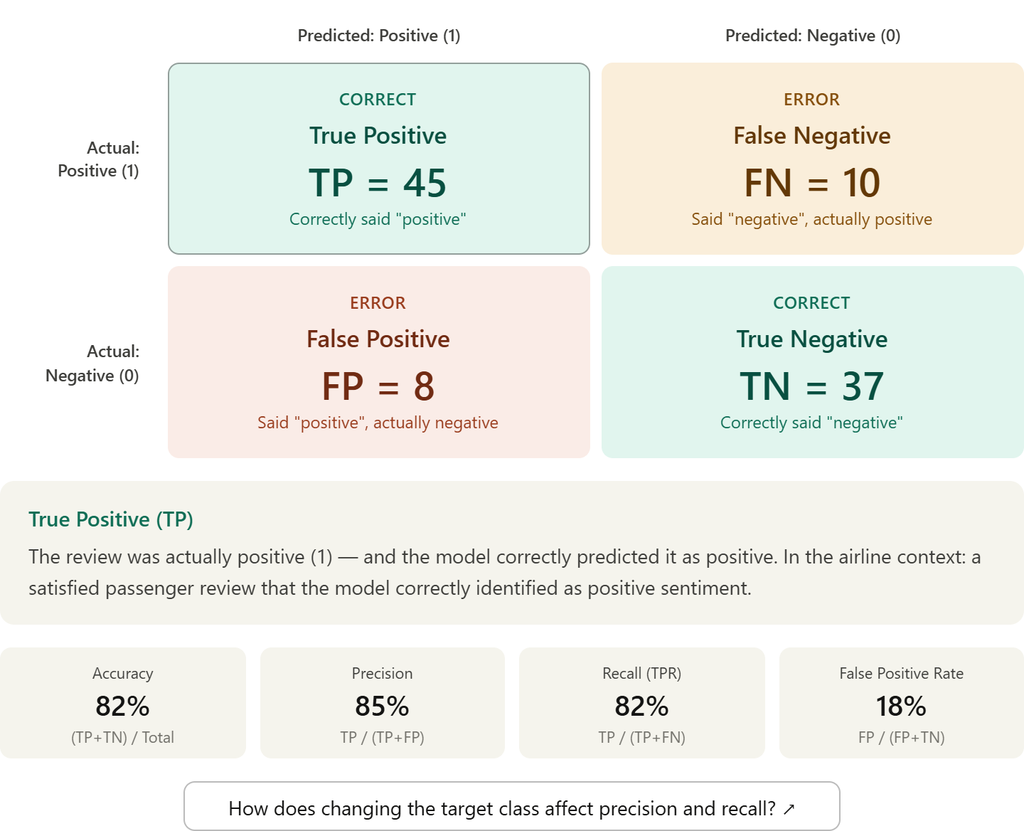

- **TP** — model predicted positive, review was actually positive. A correctly identified happy customer.
- **FP** — model predicted positive, but review was actually negative (0). A complaint wrongly flagged as praise — a Type I error.
- **FN** — model predicted negative, but review was actually positive (1). A happy customer that the model missed — a Type II error.
- **TN** — model predicted negative, review was actually negative. A correctly identified complaint.

##### 7.3.3.8.2 AUC (Area under the ROC Curve)

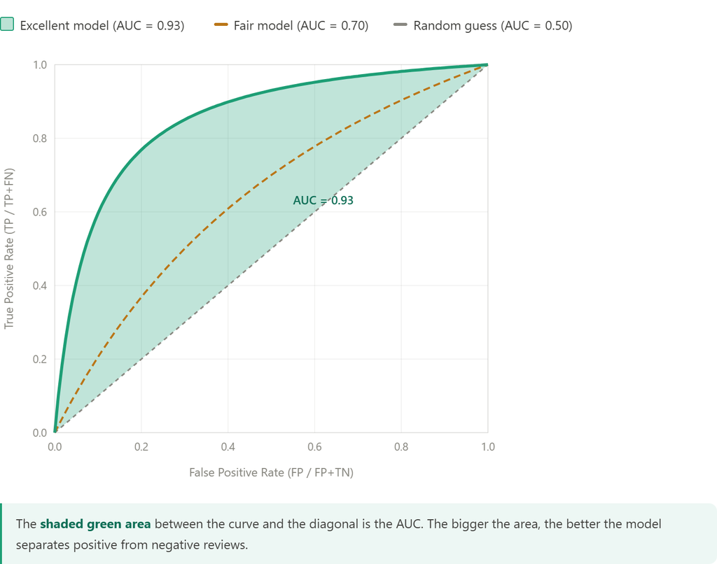

Here is what each element on the chart means:

##### 7.3.3.8.3 **ROC** (**Receiver Operating Characteristic**)

The name actually comes from **signal detection theory** developed during World War II, when radar operators needed to distinguish real enemy signals from noise. Engineers used this curve to measure how well a receiver (radar operator) could detect a true signal — hence “Receiver Operating Characteristic.”

###### 7.3.3.8.3.1 What each word means in a modern ML context

- **Receiver** — originally the radar operator or detection system; today it refers to the classifier/model doing the detecting.
- **Operating** — refers to the operating threshold — the cutoff point the model uses to decide “positive” vs “negative.” As you shift that threshold up or down, the curve traces out different TPR/FPR combinations.
- **Characteristic** — the performance characteristic of the model across all possible thresholds, not just one fixed point.

#### 7.3.3.9 Why “across all thresholds” matters

A single confusion matrix (like the one we built) only shows performance at **one specific threshold** — typically 0.5. The ROC curve asks: *what happens to TPR and FPR as we slide that threshold from 0 to 1?*

| Threshold | Effect |
| --- | --- |
| Very low (e.g. 0.1) | Model predicts positive for almost everything → high TPR but also high FPR |
| Very high (e.g. 0.9) | Model predicts positive only when very confident → low FPR but also low TPR |
| Optimal | The point on the curve closest to the top-left corner |

The AUC then summarises the model’s performance across **all** those thresholds in a single number — which is why it is more informative than accuracy at any one threshold alone.

##### 7.3.3.9.1 Thresholds

The thresholds are **not explicitly shown** on the current chart — each point on the curve corresponds to a different threshold, but the threshold values themselves are invisible. The chart below shows them.

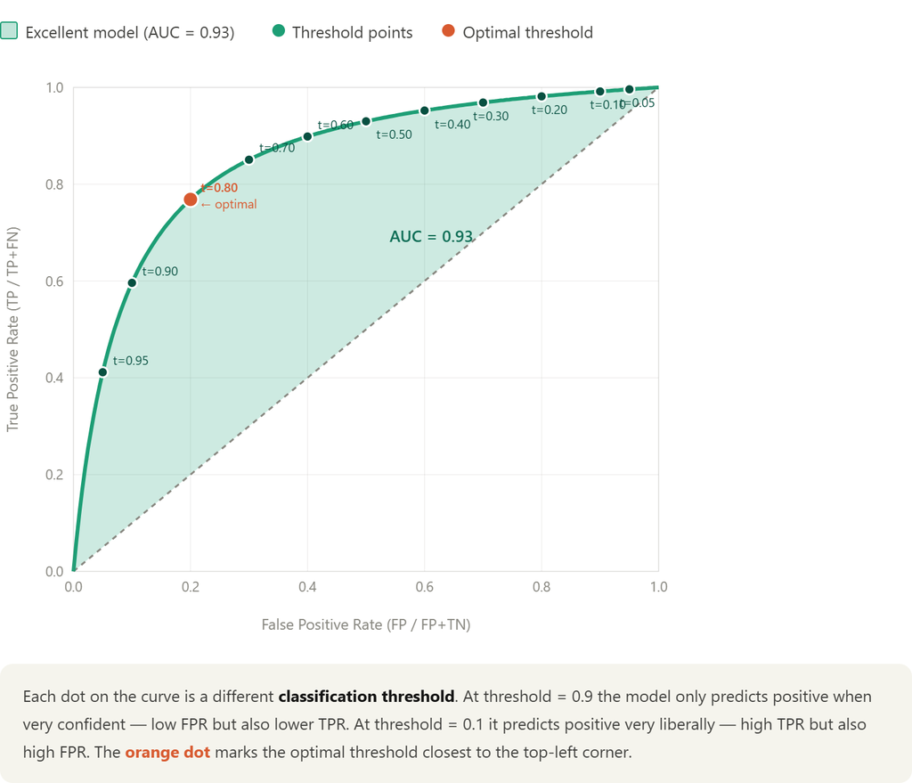

Now each dot on the curve shows its corresponding threshold value. Here is what the thresholds mean in practice:

- **High threshold (t = 0.90, 0.95)** — the model only predicts “positive review” when it is very confident. This keeps FPR low (few false alarms) but also misses more true positives, so TPR is lower. These points sit in the bottom-left of the curve.
- **Low threshold (t = 0.10, 0.05)** — the model predicts “positive” very liberally. It catches almost all true positives (high TPR) but also generates many false positives (high FPR). These points sit in the top-right of the curve.
- **Optimal threshold (orange dot)** — the point geometrically closest to the top-left corner, balancing TPR and FPR. In `glmnet` with `cv.glmnet()`, you would use this threshold when applying the model to new airline reviews.

The key insight is that **AUC summarises all these threshold trade-offs in one number** — so you do not have to commit to a single threshold just to evaluate the model.

#### 7.3.3.10 Accuracy vs. AUC

How are they different?

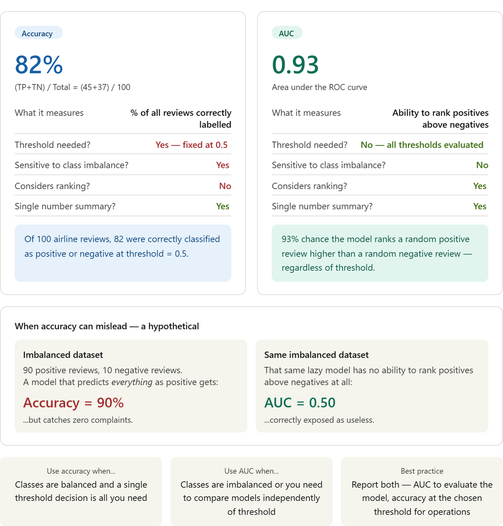

The most important distinction is this:

> **Accuracy** is a snapshot at one threshold. It answers “how often was the model right?” using the confusion matrix at a fixed cutoff (usually 0.5). In our airline example, 82 out of 100 reviews were correctly classified — but this number would change if you shifted the threshold.

> **AUC** is a full portrait across all thresholds. It answers “how good is the model at ranking?” without committing to any cutoff. The 0.93 AUC means the model’s predicted probabilities are well-ordered — positive reviews consistently score higher than negative ones.

The hypothetical in the card is the classic trap. If 90% of your airline reviews happen to be positive, a completely lazy model that always predicts “positive” achieves 90% accuracy — which sounds great but is completely useless. AUC immediately exposes it as 0.50, no better than a coin flip.

In practice, use AUC to select and compare models during training, then report accuracy once you have settled on your operational threshold for classifying incoming reviews.

## 7.4 Test Accuracy

To assess the accuracy of our model, we can again make a prediction for our test data set and see how many correctly predicted titles we get. We achieve this with the following code.

```r
it_test = tok_fun(prep_fun(test$text))
it_test = itoken(it_test, ids = test$id, progressbar = FALSE)

dtm_test = create_dtm(it_test, vectorizer)

preds = predict(glmnet_classifier, dtm_test, type = 'response')[, 1] # Returns predicted probabilities (0 to 1) rather than log-odds or class labels
glmnet:::auc(as.factor(test$sentiment), preds)
```

```
[1] 0.9123229
```

### 7.4.1 Interpretation

```
> glmnet:::auc(as.factor(test$sentiment), preds)
[1] 0.9123229
```

> The AUC produced here is the **test AUC** — the real-world performance of your model on unseen data. Comparing it to the cross-validated AUC from training (0.9203) tells you:

| Scenario | Meaning |
| --- | --- |
| Test AUC ≈ CV AUC | Model generalizes well, no overfitting |
| Test AUC << CV AUC | Model may be **overfitting** the training data |
| Test AUC >> CV AUC | Unlikely — could suggest data leakage |

## 7.5 Applying Model to New Texts

We need to again apply the same **pre-processing** to the new text as we did to our training data to enable the model to interpret it. Then we can simply apply the predict function and combine the prediction with the text.

```r
## Make Predictions for New Headlines
NewTextData = c(
  "The service was good, we had a flight without any difficulties, food was delicious, pilots were super informative",
  "Fuck Turkish Airlines, this was really the worst experience I ever had. We were super late, the plane was too croweded and service was chaotic.",
  "I really hate this airline",
  "Never again with Alitalia",
  "They really suck in all dimensions",
  "Great Service and Great Hospitality on Board",
  "Awesome Experience and really nice staff!!",
  "Best Airline ever! Will Fly Again with Qantas"
)

NewTextDataDF = data.frame(text = NewTextData, id = 4001:4008)
it_NewData = tok_fun(prep_fun(NewTextDataDF$text))
it_NewData = itoken(it_NewData, ids = NewTextDataDF$id, progressbar = FALSE)

dtm_NewData = create_dtm(it_NewData, vectorizer)

preds_NewData = predict(glmnet_classifier, dtm_NewData, type = 'class')[, 1]
NewTextDataDF$SentimentPrediction = preds_NewData
NewTextDataDF |> as_tibble()
```

| text | id | SentimentPrediction |
| --- | --- | --- |
| The service was good, we had a flight without any difficulties, food was delicious, pilots were super informative | 4001 | positive |
| Fuck Turkish Airlines, this was really the worst experience I ever had. We were super late, the plane was too croweded and service was chaotic. | 4002 | negative |
| I really hate this airline | 4003 | negative |
| Never again with Alitalia | 4004 | negative |
| They really suck in all dimensions | 4005 | negative |
| Great Service and Great Hospitality on Board | 4006 | positive |
| Awesome Experience and really nice staff!! | 4007 | positive |
| Best Airline ever! Will Fly Again with Qantas | 4008 | positive |

```r
knitr::kable(head(NewTextDataDF), "pipe")
```

| text | id | SentimentPrediction |
| --- | --- | --- |
| The service was good, we had a flight without any difficulties, food was delicious, pilots were super informative | 4001 | positive |
| Fuck Turkish Airlines, this was really the worst experience I ever had. We were super late, the plane was too croweded and service was chaotic. | 4002 | negative |
| I really hate this airline | 4003 | negative |
| Never again with Alitalia | 4004 | negative |
| They really suck in all dimensions | 4005 | negative |
| Great Service and Great Hospitality on Board | 4006 | positive |

### 7.5.1 Interpretation

Congratulations, our efforts really paid off. Our classifier correctly predicted the sentiments of all our new text input. Maybe you would like to play around a bit and try out other comments?

**Important**Question 3**:**

Playing around with different input texts, what do you believe are the boundaries of the current classifier? How could Leviev Air extend it? Or if they do not wish to do so, for which use cases can this classifier be used, for which not?

# 8 Topic Modeling with Negative Reviews

## 8.1 Introduction

> Topic Models such as **Latent Dirichlet Allocation** (LDA) or *Structural Topic Models* (STM) share the idea that documents are composed of various (latent) topics. Topic Models allow us to discover these hidden topics and to then classify each document to a topic (or various). Think about different books you like. You will be easily able to assign them each to a specific genre by remembering the content. Topic Models do the same. They rely on the content of various documents to first infer a (pre-set) number of topics to then subsequently assign the documents to the identified topics (genres).
- LDA models belong to the pioneering topic models and are today amongst the most widely applied models.
- They take the assumption that each document is composed by various words. Similarly, each topic shares a set of common words which are specific for the corresponding topic.
- The ultimate goal of the LDA is thus to **identify the various topics a document belongs to**, based on the words a document shares with a specific topic.
- LDAs belong to the group of **unsupervised machine learning** algorithms (for more details see our Churn Prediction chapter) and is thus comparable to the *cluster analysis algorithms* we witnessed in our STP chapter at the beginning of this book.

> R features multiple packages, which enable us to conduct a topic model. We recommend using the **`topicmodel` package**, as it offers the most versatile but still very approachable setup and has many useful functions integrated, that e.g. allow to parallelize processes, which will come handy, in case you face larger data sets and require to estimate multiple LDA models at the same time.

We first re-use the dataframe that only contains **negative reviews** (and which we constructed for the `word2vec` sentiment analysis). This will allow us to first focus on which topics consumers commonly dislike when flying and to then later see, which airlines face which topics/complaints most.

We again first create a **Corpus** that then contains the textual data from the reviews. We continue to apply the common text cleaning procedures that we have encountered before. Now the corpus is ready to enter the LDA.

## 8.2 Load packages

````markdown
```{r}
#| label: load-packages-topicmodels
#install.packages("ldatuning"): doesn't work since it has been removed from Cran.

# install dependecies first
#install.packages(c('Rmpfr', 'reshape2'))

# Install archived version of ldatuning

#install.packages(
#  "https://cran.r-project.org/src/contrib/Archive/ldatuning/ldatuning_1.0.2.tar.gz",
#  repos = NULL,
#  type = "source"
#)

library(topicmodels)
```
```{r}
#| label: load-packages-topicmodels
library(ldatuning)
library(tm)
```
````

## 8.3 Pre-Processing

```r
## Topic Models for Negative Reviews
Overall_corpus_Negative <- VCorpus(VectorSource(Negative_Reviews$review_text))

#Text Cleaning
Overall_corpus_clean.Negative <- tm_map(
  Overall_corpus_Negative,
  content_transformer(tolower)
)
Overall_corpus_clean.Negative <- tm_map(
  Overall_corpus_clean.Negative,
  removeNumbers
)
Overall_corpus_clean.Negative <- tm_map(
  Overall_corpus_clean.Negative,
  stemDocument
)
Overall_corpus_clean.Negative <- tm_map(
  Overall_corpus_clean.Negative,
  removeWords,
  stopwords(kind = "SMART")
)
Overall_corpus_clean.Negative <- tm_map(
  Overall_corpus_clean.Negative,
  removePunctuation
)
Overall_corpus_clean.Negative <- tm_map(
  Overall_corpus_clean.Negative,
  stripWhitespace
)

#Adapt DF for dropped documents due to cleaning
Overall_dtm.Negative <- DocumentTermMatrix(Overall_corpus_clean.Negative)

ui = unique(Overall_dtm.Negative$i)
dtm.new.negative = Overall_dtm.Negative[ui, ]
```

## 8.4 Identify Topic Numbers

Remember the k-mean cluster analysis we conducted in the STP chapter? Here we also needed to **decide apriori how many clusters we suspected** within the data set. For LDA it is the same. We need to tell the algorithm how many **latent topics** we assume to be in the data. This is not always easy, as we might have an idea, but given that we – commonly – are not able to really read all content, we often have a hard time finding an adequate number of topics.

The **`ldatuning` package** in R provides us with a straight-forward solution to do that. We simply have to determine the corridor of topics and the package will estimate all different LDA models and compare them. Keep in mind that this of course will take some time and require enough computational power. We can try it with the following code.

As you can see, we can specify in the `FindTopicsNumber()` function the corridor of topics we want to try out. Here we want to see anything between 4 and 12 topics. Feel free to try out different corridors.

To speed up the process, the same function also allows us to parallelize the estimation, which means we can estimate multiple LDA models at the same time. This however requires our computer to also have multiple CPU cores ready, as each core can take care of one model. You can adjust the `mc.cores` parameter to your specific setting. We put as default here 4, as most modern laptops have at least 4 cores or more ready.

```r
## Identify Topic Number

library(ldatuning)

negative.result <- FindTopicsNumber(
  dtm.new.negative,
  topics = seq(from = 4, to = 12, by = 1),
  metrics = c("CaoJuan2009", "Deveaud2014"),
  method = "Gibbs",
  control = list(seed = 77),
  # mc.cores represents the number of CPUs available in your computer. Feel free to adapt to your own setting!
  mc.cores = 4L,
  verbose = TRUE
)
```

```
fit models... done.
calculate metrics:
  CaoJuan2009... done.
  Deveaud2014... done.
```

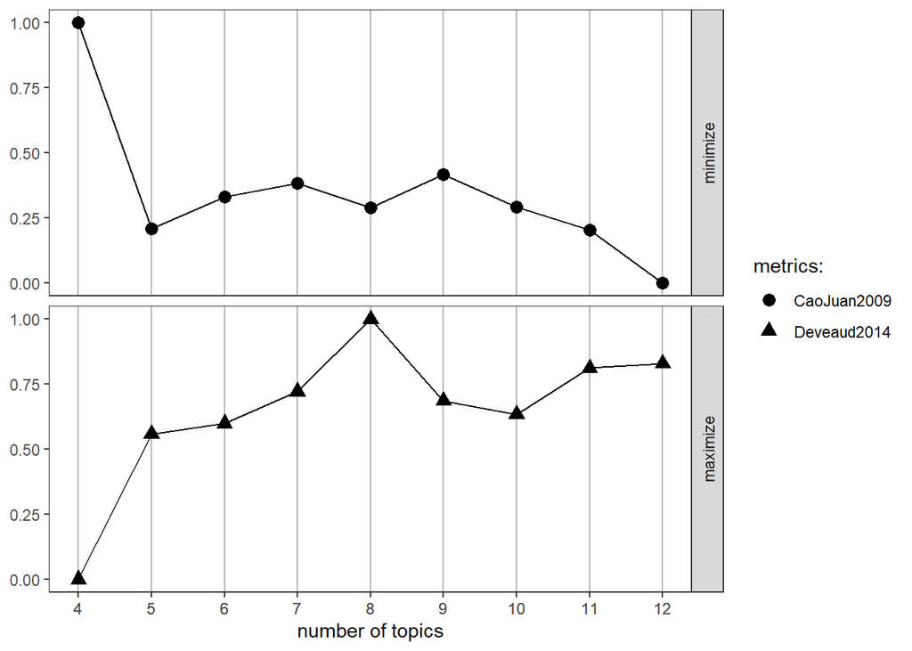

```r
FindTopicsNumber_plot(negative.result)
```

### 8.4.1 Interpretation

- *Cao measure*:

The number of topics correlates with the topic distances and thus suggest a density-based topic selection criteria that should be minimized.

- *Deceaud measure*:

Alternatively, we can focus on semantic coherence and maximize the score of Deceaud. This approach assumes that in case of models, which are semantically coherent, all topic specific words (indicated by their topic specific occurrence probability), should also co-occur within the same type of documents.

- *Output Interpretation*: Both measures provide guidance, but rarely indicate together the same solution. Here the Cao measure suggests the 12 topic solution, while the Deceaud indicator suggests a 8 topic solution (with the Cao also showing at least a local minimum for 8 topics).
- *Practical Guidance*: We suggest that you do not only base your decision on these indicators, but also on the interpretability of the LDA results.
  - Therefore, it often makes sense to subsequently estimate different LDA models (here between 8 and 12 topics) and to **focus on the usability and interpretability of the output**.
  - In the interest of space and time, we however suggest here to focus on the 8-topic solution and to continue with an 8-topic LDA as follows.

## 8.5 Running LDA

### 8.5.1 What LDA Does

LDA is an unsupervised machine learning algorithm that discovers hidden **topics** in a collection of documents. It assumes each document is a mixture of topics, and each topic is a mixture of words.

```r
library(topicmodels)
## Run LDA

k = 8
control_list_gibbs <- list(
  burnin = 2500, #set burn in
  iter = 5000, #set iterations
  seed = 1500 + seq_len(5) - 1, # vector of 5 seeds
  nstart = 5, #set random starts at 5
  best = TRUE, # return the highest probability as the result
  alpha = 50 / k,
  delta = 0.1
)

# LDA from topicmodels package
set.seed(1500)
negative_lda <- topicmodels::LDA(
  dtm.new.negative,
  k = 8,
  method = "Gibbs",
  control = control_list_gibbs
)
negative_lda
```

```
A LDA_Gibbs topic model with 8 topics.
```

### 8.5.2 Arguments Explained

**`dtm.new.negative`** — the input data

- A **Document-Term Matrix (DTM)** — rows are documents, columns are words, values are word counts
- The `negative` suffix suggests this is a subset of documents filtered by negative sentiment

**`k = 8`** — number of topics

- Tells LDA to find exactly **8 latent topics** in the corpus
- Choosing `k` is a modeling decision — too few topics are too broad, too many are too granular

**`method = "Gibbs"`** — the inference algorithm

- Uses **Gibbs Sampling**, a Markov Chain Monte Carlo (MCMC) method
- Iteratively reassigns each word to a topic based on probability
- Generally preferred over the default VEM method for better results, but slower

**`control = control_list_gibbs`** — sampler settings

- A named list of hyperparameters controlling Gibbs sampling, typically including:

| Parameter | Meaning |
| --- | --- |
| `seed` | For reproducibility |
| `burnin` | Iterations to discard before sampling |
| `iter` | Total number of iterations |
| `thin` | Keep every nth sample to reduce autocorrelation |
| `alpha` | Prior on document-topic distribution |
| `delta` / `beta` | Prior on topic-word distribution |

### 8.5.3 Interpretation

We can use the `control_list_gibbs` list to specify some of the LDA model characteristics such as the total number of iterations before the LDA stops or the seeding points for the random words.

For more details, we recommend checking the help file of the **`topicmodels` package** and the corresponding vignette. Our suggested starting points turn out to be good for ordinary models, but if you like to tweak the model further, you may try alternative `alpha` and `delta` values.

Once the model converged we can focus on the output and try to understand which topics the model identified.

### 8.5.4 Output Object

````markdown
```{r}
#| label: negative-lda-output
negative_lda

# Top terms per topic
terms(negative_lda)

# Topic proportions per document
topics(negative_lda)

## Prepare Output
tidy_negative_lda <- tidy(negative_lda)
tidy_negative_lda
```
````

```
A LDA_Gibbs topic model with 8 topics.
 Topic 1  Topic 2  Topic 3  Topic 4  Topic 5  Topic 6  Topic 7  Topic 8
"flight"   "unit" "airlin"   "seat"  "class" "flight"  "check" "ticket"
   1    2    3    4    5    6    7    8    9   10   11   12   13   14   15   16
   3    3    8    3    8    8    1    8    4    7    1    7    8    8    8    1
  17   18   19   20   21   22   23   24   25   26   27   28   29   30   31   32
   8    1    1    7    8    8    8    8    1    8    7    8    8    1    4    1
  33   34   35   36   37   38   39   40   41   42   43   44   45   46   47   48
   8    8    8    8    6    1    8    8    6    6    8    1    1    1    1    1
  49   50   51   52   53   54   55   56   57   58   59   60   61   62   63   64
   8    7    1    1    6    6    6    4    2    4    1    6    4    1    6    1
  65   66   67   68   69   70   71   72   73   74   75   76   77   78   79   80
   4    6    1    8    1    4    1    1    6    8    8    6    1    1    1    3
  81   82   83   84   85   86   87   88   89   90   91   92   93   94   95   96
   8    6    6    1    7    1    5    3    8    5    6    8    1    1    1    6
```

[output cut: 736 more lines]

| topic | term | beta |
| --- | --- | --- |
| 1 | –toronto | 2.026950e-06 |
| 2 | –toronto | 1.958626e-06 |
| 3 | –toronto | 2.014699e-06 |
| 4 | –toronto | 1.808639e-06 |
| 5 | –toronto | 2.166796e-05 |
| 6 | –toronto | 1.691813e-06 |
| 7 | –toronto | 1.760154e-06 |
| 8 | –toronto | 1.724637e-06 |
| 1 | madrid | 2.229645e-05 |
| 2 | madrid | 1.958626e-06 |

[output cut: 9990 more lines]

> The function returns an S4 object of class `LDA` containing:
- **`@beta`** — log probabilities of words per topic (topic × word matrix)
- **`@gamma`** — probabilities of topics per document (document × topic matrix)
- **`@terms`** — vocabulary (all unique words)
- **`@documents`** — document IDs
- **`@k`** — number of topics (8)

## 8.6 Plotting Top Terms Per Topic

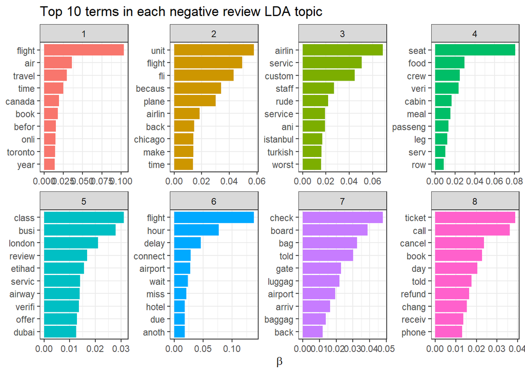

Figure 1: LDA Topic Modeling Result

```r
top_terms_negative <- tidy_negative_lda |>
  group_by(topic) |>
  top_n(10, beta) |>
  ungroup() |>
  arrange(topic, -beta)

# Visualizing
top_terms_negative |>
  mutate(term = reorder(term, beta)) |>
  group_by(topic, term) |>
  arrange(desc(beta)) |>
  ungroup() |>
  mutate(
    term = factor(
      paste(term, topic, sep = "__"),
      levels = rev(paste(term, topic, sep = "__"))
    )
  ) |>
  ggplot(aes(term, beta, fill = as.factor(topic))) +
  geom_col(show.legend = FALSE) +
  coord_flip() +
  scale_x_discrete(labels = function(x) gsub("__.+$", "", x)) +
  labs(
    title = "Top 10 terms in each negative review LDA topic",
    x = NULL,
    y = expression(beta)
  ) +
  facet_wrap(~topic, ncol = 4, scales = "free") +
  theme_bw()
```

**Important**Question 4**:**

Looking at above’s plots what kind of topics do you see here? Can you come up with meaningful topic names?

# 9 Airline Insights for Negative Reviews

## 9.1 Assignment of a topic to a Review

> To assess which topics are associated with a specific airline, we first need to assign to each review the **different topic probabilities**, which we can do with the following code.

```r
## Match Topics to Reviews

Negative_Reviews.Corrected <- Negative_Reviews[ui, ]
dim(Negative_Reviews.Corrected) # 5977 x 12
```

```
[1] 5977   12
```

```r
Negative_Reviews.wlables = cbind(Negative_Reviews.Corrected, negative_lda@gamma) # negative_lda@gamma: probabilities of topics per document (document × topic matrix): 5977 x 8

dim(Negative_Reviews.wlables) # 5977 x  20
```

```
[1] 5977   20
```

```r
Negative_Reviews.wlables |> as_tibble()
```

| ...1 | review_written | Airline | route | overall_rating | title | review_text | aircraft | type_of_traveller | seat_type | recommendation | ReviewNumb | 1 | 2 | 3 | 4 | 5 | 6 | 7 | 8 |
| --- | --- | --- | --- | --- | --- | --- | --- | --- | --- | --- | --- | --- | --- | --- | --- | --- | --- | --- | --- |
| 1 | 7th January 2021 | Air Canada | Washington to Beirut | 1 | "Very bad service and customer support" | \|Very bad service and customer support. They changed my flight once, so I changed it, understanding that there is a pandemic going on which is causing flights to change. Then they changed it again in… | NA | Solo Leisure | Economy Class | no | 1 | 0.16764706 | 0.08529412 | 0.20294118 | 0.07352941 | 0.08529412 | 0.10882353 | 0.08529412 | 0.19117647 |
| 4 | 20th December 2020 | Air Canada | St Lucia to Ottawa via Toronto | 1 | "this airline is absolutely shameful" | \| We returned from St-Lucia yesterday night, December 19th. It’s been 3 years now since we have flown with Air Canada. Due to our last few very bad experiences, we tried to avoid them at all costs. T… | NA | Couple Leisure | Economy Class | no | 4 | 0.20345745 | 0.05452128 | 0.29920213 | 0.05984043 | 0.09175532 | 0.12898936 | 0.06515957 | 0.09707447 |
| 6 | 25th November 2020 | Air Canada | Seattle to Sydney via Vancouver | 1 | "declined our request for a full refund" | \|Air Canada cancelled our flights just two days after our booking citing COVID reasons, saying the route would no longer be flown, and then charged us over $USD800 in non-refundable cancellation fees… | NA | Family Leisure | Premium Economy | no | 6 | 0.10049020 | 0.12009804 | 0.06127451 | 0.10049020 | 0.15931373 | 0.12009804 | 0.07107843 | 0.26715686 |
| 7 | 13th November 2020 | Air Canada | Shanghai to Fort Lauderdale via Montreal | 1 | "by far the worst airline I’ve ever dealt with" | \| This is by far the worst airline I’ve ever dealt with aside from Spirit. Their service at the airport moves at a glacial pace, they do absolutely nothing over the phone. And they don’t provide refu… | NA | Solo Leisure | Economy Class | no | 7 | 0.14244186 | 0.15406977 | 0.20058140 | 0.08430233 | 0.09593023 | 0.08430233 | 0.08430233 | 0.15406977 |
| 8 | 26th October 2020 | Air Canada | Sacramento to Brisbane | 1 | "Shame on you all" | \| A warning to those thinking of purchasing a ticket with Air Canada. They are in the practice of refusing to refund the purchase price even after they choose to cancel the flight. In these Covid day… | NA | Solo Leisure | Premium Economy | no | 8 | 0.18333333 | 0.07857143 | 0.09761905 | 0.06904762 | 0.16428571 | 0.07857143 | 0.07857143 | 0.25000000 |
| 9 | 12th October 2020 | Air Canada | Toronto to St Lucia | 1 | "Most unbelievable customer service" | \|We booked a flight through Air Canada for our honeymoon for 10/26. We received a flight change email from Air Canada that they changed our flight to 10/24, our wedding date! So of course we could no… | NA | Couple Leisure | Economy Class | no | 9 | 0.14380531 | 0.10840708 | 0.10840708 | 0.05530973 | 0.09070796 | 0.12610619 | 0.09955752 | 0.26769912 |
| 11 | 8th October 2020 | Air Canada | New York to Toronto | 1 | "It's disgraceful and unfair" | \| I have 3 flights booked with Air Canada for Oct 2020. Because of the Pandemic I'm not aloud to leave my country. I had a 5 month trip planned starting 1st Aug that included 21 flights. Air Canada a… | NA | Couple Leisure | Economy Class | no | 11 | 0.19250000 | 0.16250000 | 0.08250000 | 0.06250000 | 0.15250000 | 0.08250000 | 0.11250000 | 0.15250000 |
| 13 | 24th September 2020 | Air Canada | Vancouver to Quito via Toronto | 1 | "told the money is coming"" | \|Had booked a flight for mid April to fly to Ecuador. The flight was from Vancouver to Toronto, Toronto to Quito. COVID happened so they cancelled our flight from Toronto to Quito and back, There was… | NA | Couple Leisure | Economy Class | no | 13 | 0.20394737 | 0.08991228 | 0.07236842 | 0.08114035 | 0.06359649 | 0.08991228 | 0.06359649 | 0.33552632 |
| 14 | 22nd September 2020 | Air Canada | Edmonton to Toronto | 1 | "your safety is not their number one priority" | \| Man beside me refused to wear his mask properly the entire flight. He would simply slip it back on whenever the stewardess was looking. Eventually he fell asleep and I managed to point out that he … | NA | Solo Leisure | Economy Class | no | 14 | 0.18434343 | 0.08333333 | 0.07323232 | 0.21464646 | 0.06313131 | 0.09343434 | 0.17424242 | 0.11363636 |
| 16 | 30th August 2020 | Air Canada | Dublin to Edmonton via Toronto | 1 | "luggage was not taken off the flight" | \| My luggage was not taken off the flight while I was stuck in immigration. I was not notified until 6 hours after my flight had left that my luggage was flown to Edmonton airport. I was not given an… | NA | Solo Leisure | Economy Class | no | 16 | 0.16158537 | 0.10060976 | 0.10060976 | 0.08841463 | 0.07621951 | 0.16158537 | 0.21036585 | 0.10060976 |

[output cut: 5967 more lines]

```r
ldaresults.negative = as.data.frame(negative_lda@gamma)

str(Negative_Reviews.wlables)
```

```
'data.frame':   5977 obs. of  20 variables:
 $ ...1             : num  1 4 6 7 8 9 11 13 14 16 ...
 $ review_written   : chr  "7th January 2021" "20th December 2020" "25th November 2020" "13th November 2020" ...
 $ Airline          : chr  "Air Canada" "Air Canada" "Air Canada" "Air Canada" ...
 $ route            : chr  "Washington to Beirut" "St Lucia to Ottawa via Toronto" "Seattle to Sydney via Vancouver" "Shanghai to Fort Lauderdale via Montreal" ...
 $ overall_rating   : num  1 1 1 1 1 1 1 1 1 1 ...
 $ title            : chr  "\"Very bad service and customer support\"" "\"this airline is absolutely shameful\"" "\"declined our request for a full refund\"" "\"by far the worst airline I’ve ever dealt with\"" ...
 $ review_text      : chr  "|Very bad service and customer support. They changed my flight once, so I changed it, understanding that there "| __truncated__ "| We returned from St-Lucia yesterday night, December 19th. It’s been 3 years now since we have flown with Air "| __truncated__ "|Air Canada ca…
 $ aircraft         : chr  NA NA NA NA ...
 $ type_of_traveller: chr  "Solo Leisure" "Couple Leisure" "Family Leisure" "Solo Leisure" ...
 $ seat_type        : chr  "Economy Class" "Economy Class" "Premium Economy" "Economy Class" ...
 $ recommendation   : chr  "no" "no" "no" "no" ...
 $ ReviewNumb       : int  1 4 6 7 8 9 11 13 14 16 ...
 $ 1                : num  0.168 0.203 0.1 0.142 0.183 ...
 $ 2                : num  0.0853 0.0545 0.1201 0.1541 0.0786 ...
 $ 3                : num  0.2029 0.2992 0.0613 0.2006 0.0976 ...
 $ 4                : num  0.0735 0.0598 0.1005 0.0843 0.069 ...
 $ 5                : num  0.0853 0.0918 0.1593 0.0959 0.1643 ...
 $ 6                : num  0.1088 0.129 0.1201 0.0843 0.0786 ...
 $ 7                : num  0.0853 0.0652 0.0711 0.0843 0.0786 ...
 $ 8                : num  0.1912 0.0971 0.2672 0.1541 0.25 ...
```

```r
names(Negative_Reviews.wlables)[13] <- "Topic1"
names(Negative_Reviews.wlables)[14] <- "Topic2"
names(Negative_Reviews.wlables)[15] <- "Topic3"
names(Negative_Reviews.wlables)[16] <- "Topic4"
names(Negative_Reviews.wlables)[17] <- "Topic5"
names(Negative_Reviews.wlables)[18] <- "Topic6"
names(Negative_Reviews.wlables)[19] <- "Topic7"
names(Negative_Reviews.wlables)[20] <- "Topic8"

str(Negative_Reviews.wlables)
```

```
'data.frame':   5977 obs. of  20 variables:
 $ ...1             : num  1 4 6 7 8 9 11 13 14 16 ...
 $ review_written   : chr  "7th January 2021" "20th December 2020" "25th November 2020" "13th November 2020" ...
 $ Airline          : chr  "Air Canada" "Air Canada" "Air Canada" "Air Canada" ...
 $ route            : chr  "Washington to Beirut" "St Lucia to Ottawa via Toronto" "Seattle to Sydney via Vancouver" "Shanghai to Fort Lauderdale via Montreal" ...
 $ overall_rating   : num  1 1 1 1 1 1 1 1 1 1 ...
 $ title            : chr  "\"Very bad service and customer support\"" "\"this airline is absolutely shameful\"" "\"declined our request for a full refund\"" "\"by far the worst airline I’ve ever dealt with\"" ...
 $ review_text      : chr  "|Very bad service and customer support. They changed my flight once, so I changed it, understanding that there "| __truncated__ "| We returned from St-Lucia yesterday night, December 19th. It’s been 3 years now since we have flown with Air "| __truncated__ "|Air Canada ca…
 $ aircraft         : chr  NA NA NA NA ...
 $ type_of_traveller: chr  "Solo Leisure" "Couple Leisure" "Family Leisure" "Solo Leisure" ...
 $ seat_type        : chr  "Economy Class" "Economy Class" "Premium Economy" "Economy Class" ...
 $ recommendation   : chr  "no" "no" "no" "no" ...
 $ ReviewNumb       : int  1 4 6 7 8 9 11 13 14 16 ...
 $ Topic1           : num  0.168 0.203 0.1 0.142 0.183 ...
 $ Topic2           : num  0.0853 0.0545 0.1201 0.1541 0.0786 ...
 $ Topic3           : num  0.2029 0.2992 0.0613 0.2006 0.0976 ...
 $ Topic4           : num  0.0735 0.0598 0.1005 0.0843 0.069 ...
 $ Topic5           : num  0.0853 0.0918 0.1593 0.0959 0.1643 ...
 $ Topic6           : num  0.1088 0.129 0.1201 0.0843 0.0786 ...
 $ Topic7           : num  0.0853 0.0652 0.0711 0.0843 0.0786 ...
 $ Topic8           : num  0.1912 0.0971 0.2672 0.1541 0.25 ...
```

### 9.1.1 Explanations

We extract the **topic probabilities** (gammas) from the estimated LDA model and add them to the dataframe with the reviews. Finally, we renamed the columns.

### 9.1.2 Deciding a cut-off

> We can now count the occurrence of each topic in each review. To do so we have to think about, when we want to label a review, i.e. when we believe the topic probability to be high enough to say that a review contains a specific topic.

> The advantage of this approach is that we **allow reviews to contain more than one topic**, compared to other common approaches, where one labels a review only with the topic with the highest probability.

**Tip**Question 5**:**

Which value should a topic probability in this case exceed to label a review with a topic?

The **cutoff value for topic probability** is typically set based on the desired sensitivity of the topic labeling. *A common choice is 0.25*, as shown in the code snippet below.

```r
CutoffDf.Negative <- Negative_Reviews.wlables |>
  filter(
    Topic1 >= 0.25 |
      Topic2 >= 0.25 |
      Topic3 >= 0.25 |
      Topic4 >= 0.25 |
      Topic5 >= 0.25 |
      Topic6 >= 0.25 |
      Topic7 >= 0.25 |
      Topic8 >= 0.25
  )
CutoffDf.Negative$Topic1Count <- ifelse(CutoffDf.Negative$Topic1 >= 0.25, 1, 0)
CutoffDf.Negative$Topic2Count <- ifelse(CutoffDf.Negative$Topic2 >= 0.25, 1, 0)
CutoffDf.Negative$Topic3Count <- ifelse(CutoffDf.Negative$Topic3 >= 0.25, 1, 0)
CutoffDf.Negative$Topic4Count <- ifelse(CutoffDf.Negative$Topic4 >= 0.25, 1, 0)
CutoffDf.Negative$Topic5Count <- ifelse(CutoffDf.Negative$Topic5 >= 0.25, 1, 0)
CutoffDf.Negative$Topic6Count <- ifelse(CutoffDf.Negative$Topic6 >= 0.25, 1, 0)
CutoffDf.Negative$Topic7Count <- ifelse(CutoffDf.Negative$Topic7 >= 0.25, 1, 0)
CutoffDf.Negative$Topic8Count <- ifelse(CutoffDf.Negative$Topic8 >= 0.25, 1, 0)

CutoffDf.Negative |> glimpse()
```

```
Rows: 2,002
Columns: 28
$ ...1              <dbl> 4, 6, 8, 9, 13, 17, 20, 25, 27, 32, 33, 37, 40, 41, …
$ review_written    <chr> "20th December 2020", "25th November 2020", "26th Oc…
$ Airline           <chr> "Air Canada", "Air Canada", "Air Canada", "Air Canad…
$ route             <chr> "St Lucia to Ottawa via Toronto", "Seattle to Sydney…
$ overall_rating    <dbl> 1, 1, 1, 1, 1, 1, 1, 1, 1, 1, 1, 1, 1, 1, 1, 1, 1, 1…
$ title             <chr> "\"this airline is absolutely shameful\"", "\"declin…
$ review_text       <chr> "| We returned from St-Lucia yesterday night, Decemb…
$ aircraft          <chr> NA, NA, NA, NA, NA, NA, NA, NA, NA, NA, NA, NA, NA, …
$ type_of_traveller <chr> "Couple Leisure", "Family Leisure", "Solo Leisure", …
$ seat_type         <chr> "Economy Class", "Premium Economy", "Premium Economy…
$ recommendation    <chr> "no", "no", "no", "no", "no", "no", "no", "no", "no"…
$ ReviewNumb        <int> 4, 6, 8, 9, 13, 17, 20, 25, 27, 32, 33, 37, 40, 41, …
$ Topic1            <dbl> 0.2034574, 0.1004902, 0.1833333, 0.1438053, 0.203947…
$ Topic2            <dbl> 0.05452128, 0.12009804, 0.07857143, 0.10840708, 0.08…
$ Topic3            <dbl> 0.29920213, 0.06127451, 0.09761905, 0.10840708, 0.07…
$ Topic4            <dbl> 0.05984043, 0.10049020, 0.06904762, 0.05530973, 0.08…
$ Topic5            <dbl> 0.09175532, 0.15931373, 0.16428571, 0.09070796, 0.06…
$ Topic6            <dbl> 0.12898936, 0.12009804, 0.07857143, 0.12610619, 0.08…
$ Topic7            <dbl> 0.06515957, 0.07107843, 0.07857143, 0.09955752, 0.06…
$ Topic8            <dbl> 0.09707447, 0.26715686, 0.25000000, 0.26769912, 0.33…
$ Topic1Count       <dbl> 0, 0, 0, 0, 0, 1, 0, 0, 0, 0, 0, 0, 1, 0, 0, 0, 0, 0…
$ Topic2Count       <dbl> 0, 0, 0, 0, 0, 0, 0, 0, 0, 0, 0, 0, 0, 0, 0, 0, 0, 0…
$ Topic3Count       <dbl> 1, 0, 0, 0, 0, 0, 0, 0, 0, 0, 0, 0, 0, 0, 0, 0, 0, 0…
$ Topic4Count       <dbl> 0, 0, 0, 0, 0, 0, 0, 0, 0, 0, 0, 0, 0, 0, 0, 1, 0, 0…
$ Topic5Count       <dbl> 0, 0, 0, 0, 0, 0, 0, 0, 0, 0, 0, 0, 0, 0, 0, 0, 0, 0…
$ Topic6Count       <dbl> 0, 0, 0, 0, 0, 0, 0, 0, 0, 0, 0, 0, 0, 0, 0, 0, 0, 1…
$ Topic7Count       <dbl> 0, 0, 0, 0, 0, 0, 0, 0, 0, 0, 0, 0, 0, 0, 0, 0, 0, 0…
$ Topic8Count       <dbl> 0, 1, 1, 1, 1, 0, 1, 1, 1, 1, 1, 1, 0, 1, 1, 0, 1, 0…
```

### 9.1.3 Counting topics for a review

```r
# Counting
TopicCount.Negative <- CutoffDf.Negative |>
  group_by(Airline) |>
  summarize(
    Topic1 = sum(Topic1Count),
    Topic2 = sum(Topic2Count),
    Topic3 = sum(Topic3Count),
    Topic4 = sum(Topic4Count),
    Topic5 = sum(Topic5Count),
    Topic6 = sum(Topic6Count),
    Topic7 = sum(Topic7Count),
    Topic8 = sum(Topic8Count)
  )

TopicCount.Negative
```

| Airline | Topic1 | Topic2 | Topic3 | Topic4 | Topic5 | Topic6 | Topic7 | Topic8 |
| --- | --- | --- | --- | --- | --- | --- | --- | --- |
| Air Canada | 43 | 1 | 4 | 33 | 4 | 34 | 24 | 29 |
| Air France | 18 | 0 | 0 | 30 | 1 | 5 | 14 | 12 |
| Alitalia | 0 | 0 | 0 | 37 | 1 | 5 | 10 | 26 |
| British Airways | 1 | 0 | 4 | 110 | 89 | 13 | 17 | 43 |
| Emirates | 3 | 0 | 2 | 48 | 30 | 17 | 17 | 25 |
| Etihad Airways | 4 | 0 | 3 | 40 | 61 | 10 | 18 | 36 |
| Iberia | 0 | 0 | 0 | 11 | 1 | 5 | 4 | 28 |
| Lufthansa | 6 | 0 | 1 | 21 | 2 | 11 | 13 | 27 |
| Qatar Airways | 0 | 0 | 0 | 2 | 6 | 9 | 7 | 10 |
| Singapore Airlines | 1 | 0 | 0 | 12 | 15 | 2 | 3 | 8 |

[output cut: 6 more lines]

## 9.2 Get Topic Share Per Airline

> While the absolute numbers are already interesting, it may also make sense to look at the **relative shares per airlines**, which we obtain by dividing each value, by the sum of reviews per airline. We can finally achieve this with the following code.

```r
TopicCount.Negative$sum = rowSums(TopicCount.Negative[, 2:9])

TopicCount.Negative
```

| Airline | Topic1 | Topic2 | Topic3 | Topic4 | Topic5 | Topic6 | Topic7 | Topic8 | sum |
| --- | --- | --- | --- | --- | --- | --- | --- | --- | --- |
| Air Canada | 43 | 1 | 4 | 33 | 4 | 34 | 24 | 29 | 172 |
| Air France | 18 | 0 | 0 | 30 | 1 | 5 | 14 | 12 | 80 |
| Alitalia | 0 | 0 | 0 | 37 | 1 | 5 | 10 | 26 | 79 |
| British Airways | 1 | 0 | 4 | 110 | 89 | 13 | 17 | 43 | 277 |
| Emirates | 3 | 0 | 2 | 48 | 30 | 17 | 17 | 25 | 142 |
| Etihad Airways | 4 | 0 | 3 | 40 | 61 | 10 | 18 | 36 | 172 |
| Iberia | 0 | 0 | 0 | 11 | 1 | 5 | 4 | 28 | 49 |
| Lufthansa | 6 | 0 | 1 | 21 | 2 | 11 | 13 | 27 | 81 |
| Qatar Airways | 0 | 0 | 0 | 2 | 6 | 9 | 7 | 10 | 34 |
| Singapore Airlines | 1 | 0 | 0 | 12 | 15 | 2 | 3 | 8 | 41 |

[output cut: 6 more lines]

```r
WeightedTopics.Negative = data.frame(
  Airline = TopicCount.Negative$Airline,
  Topic1 = round(TopicCount.Negative$Topic1 / TopicCount.Negative$sum, 2),
  Topic2 = round(TopicCount.Negative$Topic2 / TopicCount.Negative$sum, 2),
  Topic3 = round(TopicCount.Negative$Topic3 / TopicCount.Negative$sum, 2),
  Topic4 = round(TopicCount.Negative$Topic4 / TopicCount.Negative$sum, 2),
  Topic5 = round(TopicCount.Negative$Topic5 / TopicCount.Negative$sum, 2),
  Topic6 = round(TopicCount.Negative$Topic6 / TopicCount.Negative$sum, 2),
  Topic7 = round(TopicCount.Negative$Topic7 / TopicCount.Negative$sum, 2),
  Topic8 = round(TopicCount.Negative$Topic8 / TopicCount.Negative$sum, 2)
)

# Assigning labels to topics
WeightedTopicsName.Negative = data.frame(
  Airline = TopicCount.Negative$Airline,
  Seating = round(TopicCount.Negative$Topic1 / TopicCount.Negative$sum, 2),
  Food = round(TopicCount.Negative$Topic2 / TopicCount.Negative$sum, 2),
  Delays = round(TopicCount.Negative$Topic3 / TopicCount.Negative$sum, 2),
  Customer_Service = round(
    TopicCount.Negative$Topic4 / TopicCount.Negative$sum,
    2
  ),
  Booking = round(TopicCount.Negative$Topic5 / TopicCount.Negative$sum, 2),
  USFlights = round(TopicCount.Negative$Topic6 / TopicCount.Negative$sum, 2),
  Baggage = round(TopicCount.Negative$Topic7 / TopicCount.Negative$sum, 2),
  Staff = round(TopicCount.Negative$Topic8 / TopicCount.Negative$sum, 2)
)

row.names(WeightedTopicsName.Negative) = WeightedTopicsName.Negative$Airline

WeightedTopicsName.Negative$Airline <- NULL

WeightedTopicsNameDF.Negative <- as.data.frame(t(WeightedTopicsName.Negative))

WeightedTopicsNameDF.Negative
```

|  | Air Canada | Air France | Alitalia | British Airways | Emirates | Etihad Airways | Iberia | Lufthansa | Qatar Airways | Singapore Airlines | Southwest Airlines | Swiss Airlines | Thai Airways | Turkish Airlines | United Airlines | Virgin Atlantic |
| --- | --- | --- | --- | --- | --- | --- | --- | --- | --- | --- | --- | --- | --- | --- | --- | --- |
| Seating | 0.25 | 0.22 | 0.00 | 0.00 | 0.02 | 0.02 | 0.00 | 0.07 | 0.00 | 0.02 | 0.03 | 0.18 | 0.04 | 0.02 | 0.01 | 0.00 |
| Food | 0.01 | 0.00 | 0.00 | 0.00 | 0.00 | 0.00 | 0.00 | 0.00 | 0.00 | 0.00 | 0.27 | 0.00 | 0.00 | 0.00 | 0.30 | 0.00 |
| Delays | 0.02 | 0.00 | 0.00 | 0.01 | 0.01 | 0.02 | 0.00 | 0.01 | 0.00 | 0.00 | 0.02 | 0.00 | 0.00 | 0.21 | 0.03 | 0.02 |
| Customer_Service | 0.19 | 0.38 | 0.47 | 0.40 | 0.34 | 0.23 | 0.22 | 0.26 | 0.06 | 0.29 | 0.05 | 0.38 | 0.39 | 0.17 | 0.12 | 0.66 |
| Booking | 0.02 | 0.01 | 0.01 | 0.32 | 0.21 | 0.35 | 0.02 | 0.02 | 0.18 | 0.37 | 0.01 | 0.00 | 0.13 | 0.03 | 0.01 | 0.22 |
| USFlights | 0.20 | 0.06 | 0.06 | 0.05 | 0.12 | 0.06 | 0.10 | 0.14 | 0.26 | 0.05 | 0.23 | 0.06 | 0.13 | 0.13 | 0.29 | 0.00 |
| Baggage | 0.14 | 0.17 | 0.13 | 0.06 | 0.12 | 0.10 | 0.08 | 0.16 | 0.21 | 0.07 | 0.11 | 0.06 | 0.04 | 0.16 | 0.13 | 0.03 |
| Staff | 0.17 | 0.15 | 0.33 | 0.16 | 0.18 | 0.21 | 0.57 | 0.33 | 0.29 | 0.20 | 0.27 | 0.32 | 0.26 | 0.29 | 0.10 | 0.07 |

**Important**Question 6**:**

Looking at the topic shares of negative and positive reviews, and comparing these across airlines, which topics do you believe to be essentially important for high class airlines?

## 9.3 Visualize Negative Review Topics

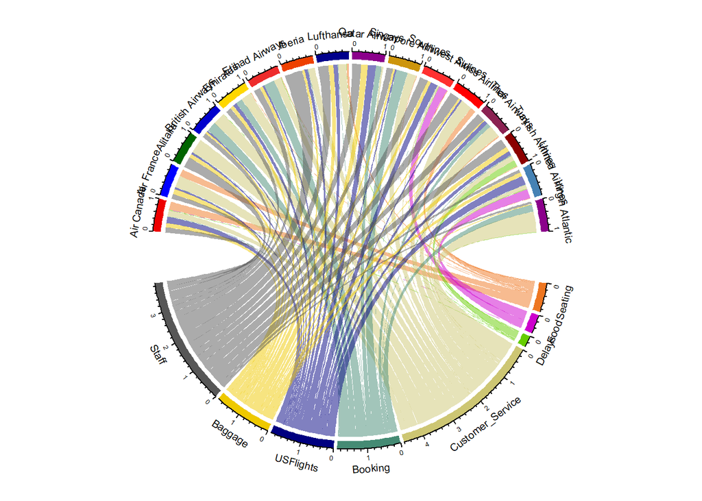

```r
library(circlize)
FinalCircDF.Negative = as.matrix(WeightedTopicsNameDF.Negative)

testcirc.Negative = data.frame(
  from = rep(
    rownames(FinalCircDF.Negative),
    times = ncol(FinalCircDF.Negative)
  ),
  to = rep(
    colnames(FinalCircDF.Negative),
    each = nrow(FinalCircDF.Negative)
  ),
  value = as.vector(FinalCircDF.Negative),
  stringsAsFactors = FALSE
)

grid.col.negative = c(
  Seating = "chocolate2",
  Food = "magenta3",
  Delays = "chartreuse3",
  Customer_Service = "khaki3",
  Booking = "aquamarine4",
  USFlights = "navy",
  Baggage = "gold2",
  Staff = "gray34",
  `Air Canada` = "red2",
  `Air France` = "blue1",
  Alitalia = "darkgreen",
  `British Airways` = "mediumblue",
  Emirates = "gold",
  `Etihad Airways` = "firebrick2",
  Iberia = "orangered2",
  Lufthansa = "blue4",
  `Qatar Airways` = "darkmagenta",
  `Singapore Airlines` = "darkgoldenrod3",
  `Southwest Airlines` = "firebrick1",
  `Swiss Airlines` = "red",
  `Thai Airways` = "violetred4",
  `Turkish Airlines` = "darkred",
  `United Airlines` = "steelblue",
  `Virgin Atlantic` = "magenta4"
)

circos.clear()
par(cex = 0.8) # size of labels outside the circle
chordDiagram(testcirc.Negative, grid.col = grid.col.negative, big.gap = 15)
```

**Important**Question 7**

What insights do you have from the chord diagram about airlines and negative topics?

# 10 Airline Insights for Positive Reviews

**Note**Tasks**

This time, apply the topic modeling procedure explained in the previous two sections (Section 8 and Section 9) to **positive reviews**.

Answer Question 4 through Question 7 again for the positive reviews. Call them Question 4b, Question 5b, Question 6b, and Qustion 7b.

# 11 Saving and Loading Files

````markdown
```{r}
#| eval: false
#| label: save-load-files
save.image("my_session.RData")
load("my_session.RData")
```
````